# Regression Models

## 13.6 Simulation 6 - Continuous Adjustment

- the following code simulates the linear model,
  $$Y_i = \beta_0 + \beta_1 x_{1i} + \beta_2 x_{2i} + \epsilon_i$$

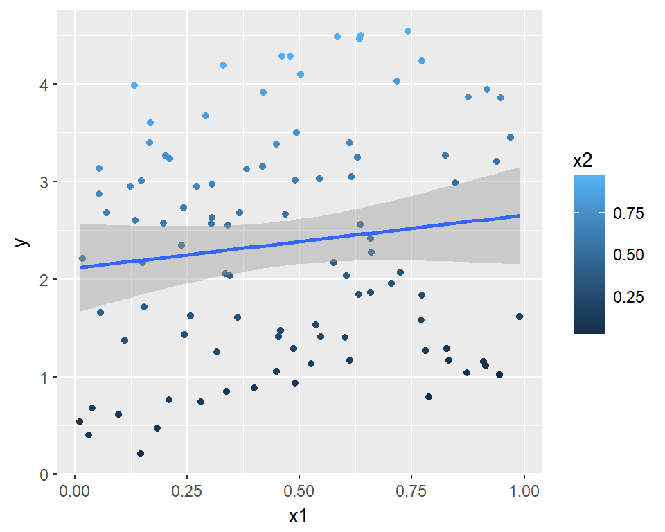

```r
# simulate data
p <- 1; n <- 100; x2 <- runif(n); x1 <- p * runif(n) - (1 - p) * x2
# define parameters/coefficients
beta0 <- 0; beta1 <- 1; beta2 <- 4 ; sigma <- .01
# generate outcome using linear model
y <- beta0 + x1 * beta1 + beta2 * x2 + rnorm(n, sd = sigma)
# plot y vs x1 and x2
qplot(x1, y) + geom_point(aes(colour=x2)) + geom_smooth(method = lm)
```

- in the above graph, we plotted $y$ vs $x_{1}$ with $x_{2}$ denoted as the gradient of color from blue to white
- to investigate the bivariate relationship more clearly, we can use the following command from the `rgl` package to generate *3D plots*

```r
rgl::plot3d(x1, x2, y)
```

- *$y$ vs $x_{1}$*

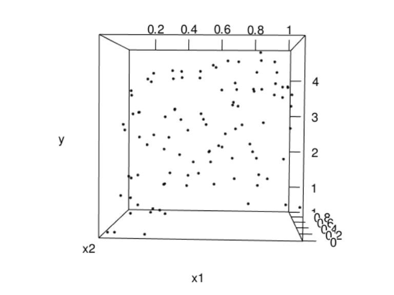

- *$y$ vs $x_{2}$*

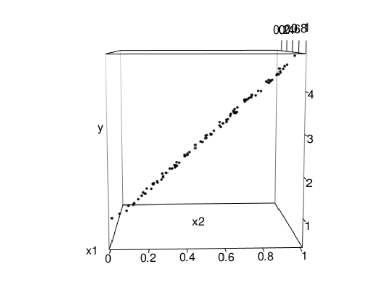

- *$x_{1}$ vs $x_{2}$*

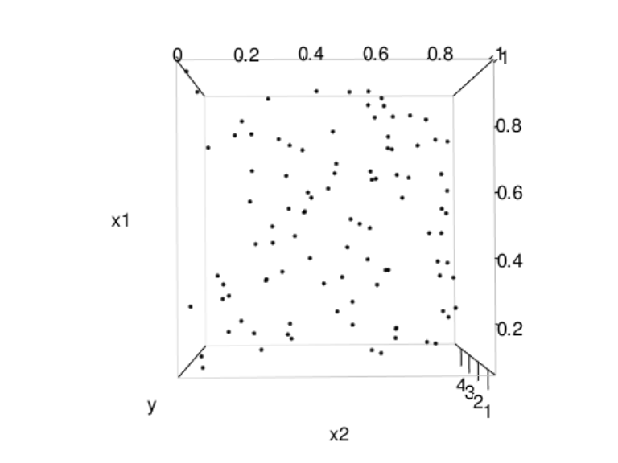

- residual plot with effect of $x_2$ removed from both $y$ and $x_1$

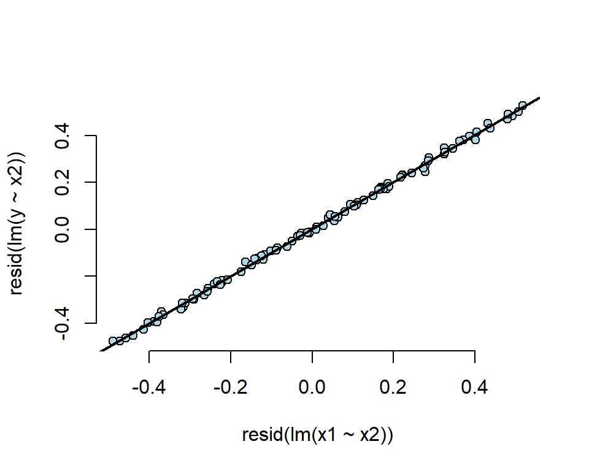

```r
# plot the residuals for y and x1 with x2 removed
plot(resid(lm(x1 ~ x2)), resid(lm(y ~ x2)), frame = FALSE,
    col = "black", bg = "lightblue", pch = 21, cex = 1)
# add linear fit line
abline(lm(I(resid(lm(y ~ x2))) ~ I(resid(lm(x1 ~ x2)))), lwd = 2)
```

## 13.7 Summary and Considerations

- modeling multivariate relationships is *difficult*
  - modeling for prediction is fairly straight forward
  - interpreting the regression lines is much harder, as adjusting for variables can have profound effect on variables of interest
- it is often recommended to explore with simulations to see how inclusion or exclusion of another variable affects the relationship of variable of interest and the outcome
- variable selection simply affects associations between outcome and predictors, using the model to formulate causal relationship are even more difficult (entire field dedicated to this $\rightarrow$ *causal inference*)

# 14 Residuals and Diagnostics

- recall that the **generalized linear model** is defined as
  $$Y_i = \sum_{k=1}^p X_{ik} \beta_j + \epsilon_{i}$$
  where $\epsilon_i \stackrel{iid}{\sim} N(0, \sigma^2)$
- the **predicted outcome**, $\hat Y_i$, is defined as
  $$\hat Y_i = \sum_{k=1}^p X_{ik} \hat \beta_j$$
- the **residuals**, $e_i$, is defined as
  $$e_i = Y_i - \hat Y_i = Y_i - \sum_{k=1}^p X_{ik} \hat \beta_j$$
- the unbiased estimate for **residual variation** is defined as
  $$\hat \sigma^2_{resid} = \frac{\sum_{i=1}^n e_i^2}{n-p}$$
  where the denominator is $n-p$ so that $E[\hat \sigma^2] = \sigma^2$
- to evaluate the fit and residuals of a linear model generated by R (i.e. `fit <- lm(y~x)`, we can use the `plot(fit)` to produce a series of *4 diagnostic plots*
  - *Residuals vs Fitted* = plots ordinary residuals vs fitted values $\rightarrow$ used to detect patterns for missing variables, heteroskedasticity, etc
  - *Scale-Location* = plots standardized residuals vs fitted values $\rightarrow$ similar residual plot, used to detect patterns in residuals
  - *Normal Q-Q* = plots theoretical quantiles for standard normal vs actual quantiles of standardized residuals $\rightarrow$ used to evaluate normality of the errors
  - *Residuals vs Leverage* = plots **cooks distances** comparison of fit at that point vs potential for influence of that point $\rightarrow$ used to detect any points that have substantial influence on the regression model
- *Example*

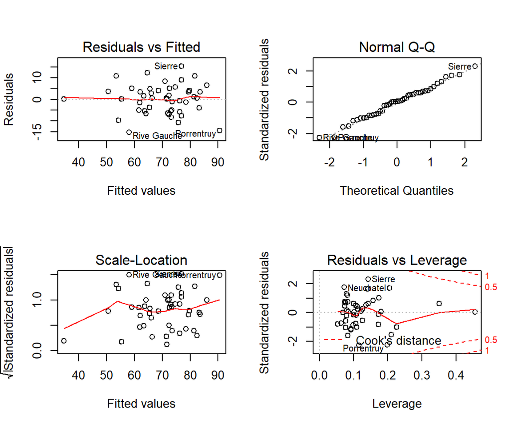

```r
# load swiss data and
data(swiss)
# run linear regression on Fertility vs all other predictors
fit <- lm(Fertility ~ . , data = swiss)
# generate diagnostic plots in 2 x 2 panels
par(mfrow = c(2, 2)); plot(fit)
```

## 14.1 Outliers and Influential Points

- **outlier** = an observation that is distant from the other observations of the data set
  - can be results of [spurious](http://en.wikipedia.org/wiki/Spurious_relationship) or real processes
  - can conform to the regression relationship (i.e being marginally outlying in X or Y, but not outlying given the regression relationship)

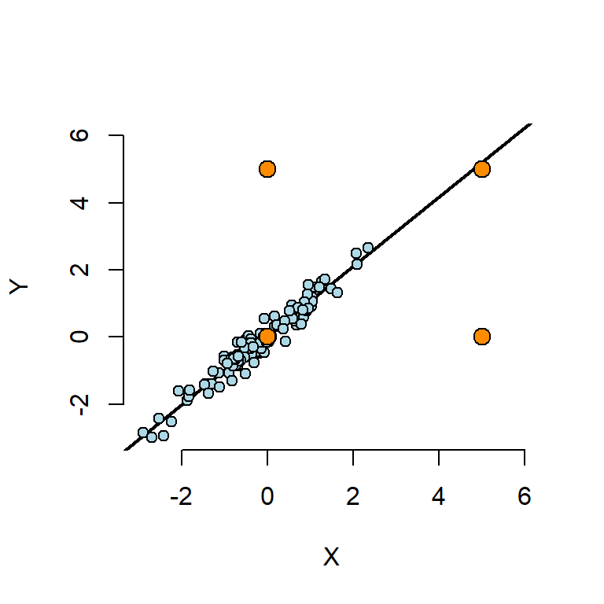

```r
# generate data
n <- 100; x <- rnorm(n); y <- x + rnorm(n, sd = .3)
# set up axes
plot(c(-3, 6), c(-3, 6), type = "n", frame = FALSE, xlab = "X", ylab = "Y")
# plot regression line for y vs x
abline(lm(y ~ x), lwd = 2)
# plot actual (x, y) pairs
points(x, y, cex = 1, bg = "lightblue", col = "black", pch = 21)
# plot 4 points of interest
points(0, 0, cex = 1.5, bg = "darkorange", col = "black", pch = 21)
points(0, 5, cex = 1.5, bg = "darkorange", col = "black", pch = 21)
points(5, 5, cex = 1.5, bg = "darkorange", col = "black", pch = 21)
points(5, 0, cex = 1.5, bg = "darkorange", col = "black", pch = 21)
```

- different outliers can have *varying* degrees of *influence*
  - **influence** = actual effect on model fit
  - **leverage** = potential for influence
- in the plot above, we examine 4 different points of interest (in orange)
  - **lower left**: low leverage, low influence, *not* an outlier in any sense
  - **upper left**: low leverage, low influence, classified as outlier because it does not conform to the regression relationship
    - **Note**: this point, though far away from the rest, **does not** impact the regression line since it lies in the middle of the data range because the regression line must always pass through the mean/center of observations
  - **upper right**: high leverage, low influence, classified as outlier because it lies far away from the rest of the data
    - **Note**: this point has low influence on regression line because it conforms to the overall regression relationship
  - **lower right**: high leverage, high influence, classified as outlier because it lies far away from the rest of the data AND it does not conform to the regression relationship

## 14.2 Influence Measures

- there exists many pre-written functions to measure influence of observations already in the `stats` package in R
  - **Note**: typing in `?influence.measures` in R will display the detailed documentation on all available functions to measure influence
  - **Note**: the `model` argument referenced in the following functions is simply the linear fit model generated by the `lm` function (i.e. `model <- lm(y~x`)
  - `rstandard(model)` = standardized residuals $\rightarrow$ residuals divided by their standard deviations
  - `rstudent(model)` = standardized residuals $\rightarrow$ residuals divided by their standard deviations, where the $i^{th}$ data point was deleted in the calculation of the standard deviation for the residual to follow a t distribution
  - `hatvalues(model)` = measures of leverage; “how far it is away”
  - `dffits(model)` = change in the predicted response when the $i^{th}$ point is deleted in fitting the model
    - effectively measures influence of a point on prediction
  - `dfbetas(model)` = change in individual coefficients when the $i^{th}$ point is deleted in fitting the model, standardized by a deleted estimate of the coefficient standard error
    - effectively measures influence of the individual coefficients
  - `dfbeta(model)` = difference in coefficients for including vs excluding each data point (unscaled version of `dfbetas`, ie. not standardized)
  - `cooks(model).distance` = overall change in coefficients when the $i^{th}$ point is deleted
  - `resid(model)` = returns ordinary residuals
  - `resid(model)/(1-hatvalues(model))` = returns *PRESS* residuals (i.e. the leave one out **cross validation residuals**)
    - PRESS residuals measure the differences in the response and the predicted response at data point $i$, where it was not included in the model fitting
    - effectively measures the prediction error based on model constructed with every other point but the one of interest
- **Note**: `swirl` lesson digs deeper into the manual calculations of `dfbeta`, `hatvalues`, `rstandard`, `rstudent` and `cooks(model).distance`

## 14.3 Using Influence Measures

- The purpose of these functions are to probe the given data in different ways to *diagnose* different problems
  - patterns in **residual plots** (most important tool) $\rightarrow$ generally indicate some poor aspect of model fit
    - heteroskedasticity $\rightarrow$ non-constant variance
    - missing model terms
    - temporal patterns $\rightarrow$ residuals versus collection order/index exhibit pattern
  - **residual Q-Q plots** plots theoretical quantile vs actual quantiles of residuals
    - investigates whether the errors follow the standard normal distribution
  - **leverage measures** (hat values) measures the potential to influence the regression model
    - only depend on $x$ or predictor variables
    - can be useful for diagnosing data entry errors
  - **influence measures** (i.e. dfbetas) measures actual influence of points on a particular aspect of the regression model
    - evaluates how deleting or including this point impact a particular aspect of the model
- Be wary of simplistic rules for diagnostic plots and measures. The use of these tools is *context specific*. It’s better to understand what they are trying to accomplish and use them judiciously (have a *hollistic view*).
- Not all measures have *meaningful absolute scales*, so it may be useful to apply these measures to different values in the same data set but *almost never* to different datasets

## 14.4 Example - Outlier Causing Linear Relationship

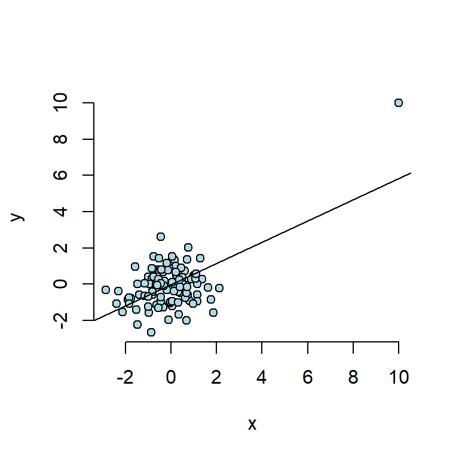

```r
# generate random data and point (10, 10)
x <- c(10, rnorm(n)); y <- c(10, c(rnorm(n)))
# plot y vs x
plot(x, y, frame = FALSE, cex = 1, pch = 21, bg = "lightblue", col = "black")
# perform linear regression
fit <- lm(y ~ x)
# add regression line to plot
abline(fit)
```

- data generated
  - 100 points are randomly generated from the standard normal distribution
  - point (10, 10) added to the data set
- there is no regression relationship between X and Y as the points are simply random noise
- the regression relationship was able to be constructed precisely because of the presence of the point (10, 10)
  - $R^2$ = 0.3593752
  - a single point has created a strong regression relationship where there shouldn’t be one
    - point (10, 10) has high leverage and high influence
  - we can use diagnostics to detect this kind of behavior
- `dfbetas(fit)` = difference in coefficients for including vs excluding each data point
  - the function will return a `n x m` dataframe, where n = number of values in the original dataset, and m = number of coefficients
  - for this example, the coefficients are $\beta_0$ (intercept), and $\beta_1$ (slope), and we are interested in the slope

```r
# calculate the dfbetas for the slope the first 10 points
round(dfbetas(fit)[1 : 10, 2], 3)
```

```
##      1      2      3      4      5      6      7      8      9     10
##  6.488  0.000 -0.074  0.018  0.048  0.016 -0.009 -0.099  0.027 -0.049
```

- as we can see from above, the slope coefficient would *change dramatically* if the first point (10, 10) is left out
- `hatvalues(fit)` = measures the potential for influence for each point

```r
# calculate the hat values for the first 10 points
round(hatvalues(fit)[1 : 10], 3)
```

```
##     1     2     3     4     5     6     7     8     9    10
## 0.517 0.010 0.011 0.010 0.013 0.010 0.010 0.017 0.011 0.020
```

- again, as we can see from above, the *potential for influence is very large* for the first point (10, 10)

**Manual calculations of Influence Measures**

- `dfbeta(fit)` = difference in coefficients for including vs excluding each data point (unscaled)

```r
# exclude outlier in the first element
fitno <- lm(y ~ x, data.frame(y = y[-1], x = x[-1]))
# manually calculate the difference in coefficients
df.diff <- coef(fit)-coef(fitno)
# using dfbeta function to do the same
df.beta <- dfbeta(fit)[1,]
rbind("manually" = df.diff, "dfbeta" = df.beta)
```

```
##          (Intercept)         x
## manually   0.1133938 0.4328801
## dfbeta     0.1133938 0.4328801
```

- manually calculate `hatvalue` for the 1st element (outlier)
  - hatvalue = 1 minus the ratio of residuals (is a measure of influence and a value between 1 and 0)
    - near 0 for points which are not influential
    - near 1 for points which are influential

```r
# calculate residual from model without outlier by plugging outlier into fitted model
resno <- y[1] - predict(fitno, data.frame(x = x[1]))
# 1 minus ratio of residual of fit inclusive outlier (numerator) to residual of fit exclusive outlier (denominator)
hat.manual <- 1-resid(fit)[1]/resno
# using hatvalues function to do the same
hat.values <- hatvalues(fit)[1]
rbind("manually" = hat.manual, "hatvalues" = hat.values)
```

```
##                   1
## manually  0.5165582
## hatvalues 0.5165582
```

- Residuals of individual samples are sometimes treated as having the same variance, which is estimated as the sample variance of the entire set of residuals. Theoretically, however, residuals of individual samples have different variances and these differences can become large in the presence of outliers
  - Standardized and Studentized residuals attempt to compensate for this effect in two slightly different ways. Both use hat values
- `rstandard(model)` = standardized residuals $\rightarrow$ residuals divided by their standard deviations

```r
# Calculate standardized residuals
# First, calculate the sample standard deviation of fit's residual by dividing fit's deviance
# i.e., its residual sum of squares, by the residual degrees of freedom and taking the square root
sigma <- sqrt(deviance(fit)/df.residual(fit))
# estimate standard deviations of individual samples (=standardized residuals)
rstd <- resid(fit)/(sigma * sqrt(1-hatvalues(fit)))
# using rstandard function to do the same as above
r.standard <- rstandard(fit)
rbind("manually" = rstd[1], "rstandard" = r.standard[1])
```

```
##                  1
## manually  5.364662
## rstandard 5.364662
```

- `rstudent(model)` = standardized residuals $\rightarrow$ residuals divided by their standard deviations, where the $i^{th}$ data point was deleted in the calculation of the standard deviation for the residual to follow a t distribution

```r
# Calculate (externally) Studentized residuals (in this example we leave the outlier out)
# Recalling that the model we called fitno omits the outlier sample
# Calculate the sample standard deviation of fitno's residual by dividing its deviance, by its
# residual degrees of freedom and taking the square root
sigma1 <- sqrt(deviance(fitno)/df.residual(fitno))
# Calculate the Studentized residual for the outlier sample
rstdt <- resid(fit)/(sigma1 * sqrt(1-hatvalues(fit)))
# using rstudent function to do the same as above
r.student <- rstudent(fit)
rbind("manually" = rstdt[1], "rstudent" = r.student[1])
```

```
##                 1
## manually 6.337583
## rstudent 6.337583
```

- `cooks(model).distance` = overall change in coefficients when the $i^{th}$ point is deleted
  - It is essentially the sum of squared differences between values fitted with and without a particular sample
  - It is normalized (divided by) residual sample variance times the number of predictors (in our example 2, that is intercept and x)
  - It essentially tells how much a given sample changes a model

```r
# Calculate the difference in predicted values between fit and fitno,
# the models which respectively include and omit the outlier
dy <- predict(fitno, data.frame(x = x)) - predict(fit, data.frame(x = x))
# Calculate the outlier's Cook's distance
cook.manual <- sum(dy^2)/(2*sigma^2)
# using cook.distance function to do the same as above
cook.dist <- cooks.distance(fit)[1]
rbind("manually" = cook.manual, "cook.distance" = cook.dist)
```

```
##                      1
## manually      15.37552
## cook.distance 15.37552
```

## 14.5 Example - Real Linear Relationship

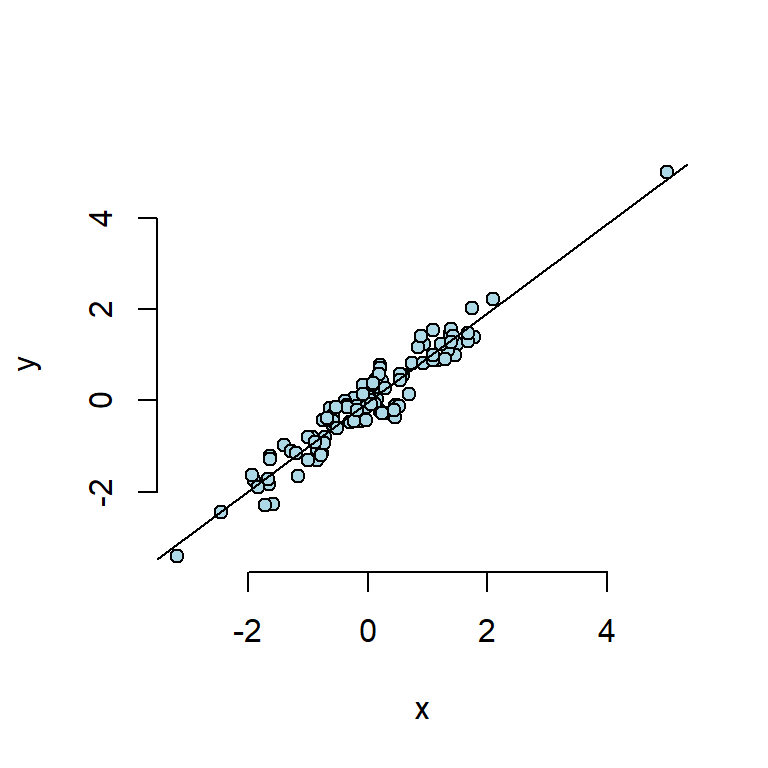

```r
# generate data
x <- rnorm(n); y <- x + rnorm(n, sd = .3)
# add an outlier that fits the relationship
x <- c(5, x); y <- c(5, y)
# plot the (x, y) pairs
plot(x, y, frame = FALSE, cex = 1, pch = 21, bg = "lightblue", col = "black")
# perform the linear regression
fit2 <- lm(y ~ x)
# add the regression line to the plot
abline(fit2)
```

- data generated
  - 100 directly correlated points are generated
  - point (5, 5) added to the data set
- there is a linear relationship between X and Y
  - $R^2$ = 0.9253067
  - point (5, 5) has high leverage and low influence

```r
# calculate the dfbetas for the slope the first 10 points
round(dfbetas(fit2)[1 : 10, 2], 3)
```

```
##      1      2      3      4      5      6      7      8      9     10
##  0.243 -0.151  0.102 -0.074  0.026 -0.065 -0.163  0.006 -0.085  0.010
```

```r
# calculate the hat values for the first 10 points
round(hatvalues(fit2)[1 : 10], 3)
```

```
##     1     2     3     4     5     6     7     8     9    10
## 0.197 0.033 0.016 0.026 0.014 0.020 0.026 0.010 0.013 0.022
```

- as we can see from above, the point (5, 5) no longer has a large `dfbetas` value (indication of low influence) but still has a substantial `hatvalue` (indication of high leverage)
  - this is in line with our expectations

## 14.6 Example - Stefanski TAS 2007

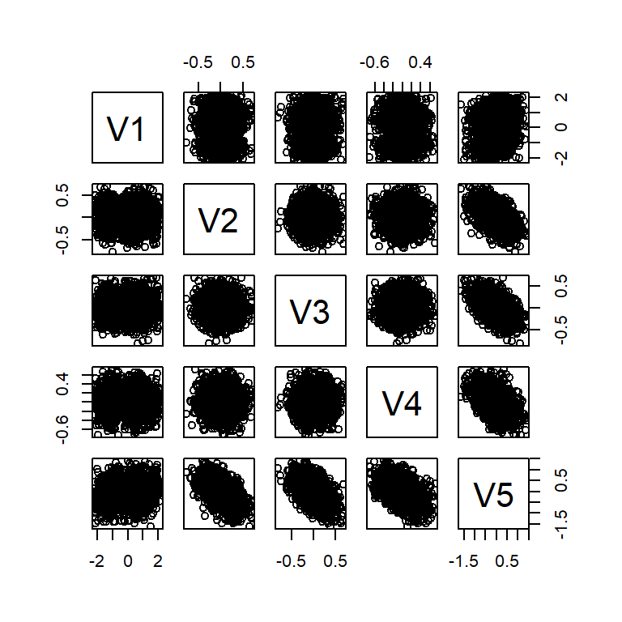

```r
# read data
data <- read.table('http://www4.stat.ncsu.edu/~stefanski/NSF_Supported/Hidden_Images/orly_owl_files/orly_owl_Lin_4p_5_flat.txt',
    header = FALSE)
# construct pairwise plot
pairs(data)
```

```r
# perform regression on V1 with all other predictors (omitting the intercept)
fit <- lm(V1 ~ . - 1, data = data)
# print the coefficient for linear model
summary(fit)$coef
```

```
##     Estimate Std. Error   t value     Pr(>|t|)
## V2 0.9856157 0.12798121  7.701253 1.989126e-14
## V3 0.9714707 0.12663829  7.671225 2.500259e-14
## V4 0.8606368 0.11958267  7.197003 8.301184e-13
## V5 0.9266981 0.08328434 11.126919 4.778110e-28
```

- as we can see from above, the p-values for the coefficients indicate that they are significant
- if we take a look at the residual plot, an interesting pattern appears

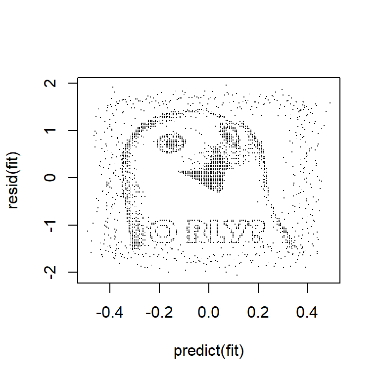

```r
# plot the residuals vs fitted values
plot(predict(fit), resid(fit), pch = '.')
```

# 15 Model Selection

> “A model is a lense through which to look at your data” – **Scott Zeger**

> “There’s no such thing as a correct model” – **Brian Caffo**
- **Intro**: These lectures represents a challenging question: “How do we chose what variables to include in a regression model?”. Sadly, no single easy answer exists and the most reasonable answer would be “It depends.”. These concepts bleed into ideas of machine learning, which is largely focused on high dimensional variable selection and weighting. In the following lectures we cover some of the basics and, most importantly, the consequences of over- and under-fitting a model.
- We have an entire class on prediction and machine learning, so we’ll focus on modeling.
  - Prediction has a different set of criteria, needs for interpretability and standards for generalizability
  - **goal for modeling** = find *parsimonious, interpretable representations* of data that enhance our understanding of the phenomena under study
  - whichever model connects data to a true, parsimonious statement would be *best* model
- there are nearly uncontable ways that a model can be wrong, in this lecture, we’ll focus on variable inclusion and exclusion.
- like nearly all aspects of statistics, good modeling decisions are context dependent
- good model for prediction $\neq$ model to establish causal effects
  - prediction model may tolerate more variables and variability

## 15.1 Rumsfeldian Triplet

> “There are known knowns. These are things we know that we know. There are known unknowns. That is to say, there are things that we know we don’t know. But there are also unknown unknowns. There are things we don’t know we don’t know.” – **Donald Rumsfeld**
- **known knowns** = regressors that we know and have, which will be evaluated to be included in the model
- **known unknowns** = regressors that we don’t have but would like to include in the model
  - didn’t or couldn’t collect the data
- **unknown unknowns** = regressors that we don’t know about that we should have included in the model

## 15.2 General Rules

- **omitting variables** $\rightarrow$ generally results in *increased bias* in the coefficients of interest
  - exceptions are when the omitted variables are uncorrelated with the regressors (variables of interest/included in model)
    - **Note**: this is why randomize treatments/trials/experiments are the norm; it’s the best strategy to balance confounders, or maximizing the probability that the treatment variable is uncorrelated with variables not in the model
    - often times, due to experiment conditions or data availability, we cannot randomize
    - however, if there are too many unobserved confounding variables, even randomization won’t help
- **including irrelevant/unnecessary variables** $\rightarrow$ generally *increases standard errors* (estimated standard deviation) of the coefficients
  - **Note**: including **any** new variables increases true standard errors of other regressors, so it is not wise to idly add variables into model
- whenever highly correlated variables are included in the same model $\rightarrow$ the standard error and therefore the *variance* of the model *increases* $\rightarrow$ this is known as **variance inflation**
  - actual increase in standard error of coefficients for adding a regressor = estimated by the ratio of the estimated standard errors minus 1, or in other words
    $$\Delta_{\sigma~|~adding~x_2} = \frac{\hat \sigma_{y \sim x_1+x_2}}{\hat \sigma_{y \sim x_1}} - 1$$
    for all coefficients for the regression model
    - *Example*: if standard error of the $\beta_1$ of `y~x1+x2` = 1.5 and standard error for the $\beta_1$ of `y~x1` = 0.5, then the actual increase in standard error of the $\beta_1$ = 1.5/0.5 - 1 = 200%
  - **Note**: when the regressors added are orthogonal (statistically independent) to the regressor of interest, then there is no variance inflation
    - **variance inflation factor** (VIF) = the increase in the variance for the $i_{th}$ regressor compared to the ideal setting where it is orthogonal to the other regressors
    - $\sqrt{VIF}$ = increase in standard error
  - **Note**: variance inflation is only part of the picture in that sometimes we will **include variables** even though they dramatically inflate the variation because it is an **empirical part of the relationship** we are attempting to model
- as the number of *non-redundant* variables approaches $n$, the model *approaches a perfect fit* for the data
  - $R^2$ increases monotonically as more regressors are included
  - Sum of Squared Errors (SSE) decreases monotonically as more regressors are included

## 15.3 Example - $R^2$ v $n$

- for the simulation below, no actual regression relationship exist as the data generated are simply standard normal noise
- it is clear, however, that as $p$, the number of regressors included in the model, approaches $n$, the $R^2$ value approaches 1.0, which signifies perfect fit

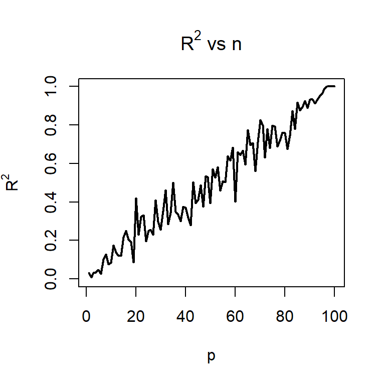

```r
# set number of measurements
n <- 100
# set up the axes of the plot
plot(c(1, n), 0 : 1, type = "n", xlab = "p", ylab = expression(R^2),
    main = expression(paste(R^2, " vs n")))
# for each value of p from 1 to n
r <- sapply(1 : n, function(p){
    # create outcome and p regressors
    y <- rnorm(n); x <- matrix(rnorm(n * p), n, p)
    # calculate the R^2
    summary(lm(y ~ x))$r.squared
})
# plot the R^2 values and connect them with a line
lines(1 : n, r, lwd = 2)
```

## 15.4 Adjusted $R^2$

- recall that $R^2$ is defined as the percent of total variability that is explained by the regression model, or
  $$R^2 = \frac{\mbox{regression variation}}{\mbox{total variation}} = 1- \frac{\sum_{i=1}^n (Y_i - \hat Y_i)^2}{\sum_{i=1}^n (Y_i - \bar Y)^2} = 1 - \frac{Var(e_i)}{Var(Y_i)}$$
- Estimating $R^2$ with the above definition is *acceptable* when there is a *single* variable, but it becomes less and *less helpful* as the *number of variables increases*
  - as we have shown previously, $R^2$ always increases as more variables are introduced and is thus *biased*
- **adjusted $R^2$** is a better estimate of variability explained by the model and is defined as
  $$R^2_{adj} = 1 - \frac{Var(e_i)}{Var(Y_i)} \times \frac{n-1}{n-k-1}$$
  where $n$ = number of observations, and $k$ = number of predictors in the model
  - since $k$ is always greater than zero, the adjusted $R^2$ is *always smaller* than the unadjusted $R^2$
  - adjusted $R^2$ also penalizes adding large numbers of regressors, which would have inflated the unadjusted $R^2$

## 15.5 Example - Unrelated Regressors

- in the simulation below, outcome $y$ is only related to $x_1$
  - $x_2$ and $x_3$ are random noise
- we will run 1000 simulations of 3 linear regression models, and calculate the *standard error of the slope*
  - $y$ vs $x_1$
  - $y$ vs $x_1 + x_2$
  - $y$ vs $x_1 + x_2 + x_3$

```r
# simulate data
n <- 100; nosim <- 1000
# generate 3 random noise, unrelated variables
x1 <- rnorm(n); x2 <- rnorm(n); x3 <- rnorm(n);
# calculate beta1s of three different regression
betas <- sapply(1 : nosim, function(i){
    # generate outcome as only related to x1
    y <- x1 + rnorm(n, sd = .3)
    # store beta1 of linear regression on y vs x1
    c(coef(lm(y ~ x1))[2],
        # store beta1 of linear regression on y vs x1 and x2
        coef(lm(y ~ x1 + x2))[2],
        # store beta1 of linear regression on y vs x1 x2 and x3
        coef(lm(y ~ x1 + x2 + x3))[2])
})
# calculate the standard error of the beta1s for the three regressions
beta1.se <- round(apply(betas, 1, sd), 5)
# print results
rbind("y ~ x1" = c("beta1SE" = beta1.se[1]),
      "y ~ x1 + x2" = beta1.se[2],
      "y ~ x1 + x2 + x3" = beta1.se[3])
```

```
##                  beta1SE.x1
## y ~ x1              0.03043
## y ~ x1 + x2         0.03077
## y ~ x1 + x2 + x3    0.03078
```

- as we can see from the above result, if we include unrelated/uncorrelated regressors $x_2$ and $x_3$, the *standard error remains the same*, in other words there is no variance inflation. This is because the other regressors, x2 and x3, are uncorrelated with the regressor of interest, x1.

## 15.6 Example - Highly Correlated Regressors / Variance Inflation

- in the simulation below, outcome $y$ is related to $x_1$
  - $x_2$ and $x_3$ are highly correlated with $x_1$
  - $x_3$ is more correlated with $x_1$ than $x_2$
- we will run 1000 simulations of 3 linear regression models, and calculate the *standard error of $\beta_1$*, the coefficient of $x_1$
  - $y$ vs $x_1$
  - $y$ vs $x_1 + x_2$
  - $y$ vs $x_1 + x_2 + x_3$

```r
# generate number of measurements and trials
n <- 100; nosim <- 1000
# generate random variables that are correlated with x1
x1 <- rnorm(n)
x2 <- x1/sqrt(2) + rnorm(n) /sqrt(2)
x3 <- x1 * 0.95 + rnorm(n) * sqrt(1 - 0.95^2)
# calculate the beta1s for 1000 trials
betas <- sapply(1 : nosim, function(i){
    # generate outcome as only related to x1
    y <- x1 + rnorm(n, sd = .3)
    # store beta1 of linear regression on y vs x1
    c(coef(lm(y ~ x1))[2],
        # store beta1 of linear regression on y vs x1 and x2
        coef(lm(y ~ x1 + x2))[2],
        # store beta1 of linear regression on y vs x1 x2 and x3
        coef(lm(y ~ x1 + x2 + x3))[2])
})
# calculate the standard error of the beta1 for the three regressions
beta1.se <- round(apply(betas, 1, sd), 5)
# print results
rbind("y ~ x1" = c("beta1SE" = beta1.se[1]),
      "y ~ x1 + x2" = beta1.se[2],
      "y ~ x1 + x2 + x3" = beta1.se[3])
```

```
##                  beta1SE.x1
## y ~ x1              0.03068
## y ~ x1 + x2         0.04014
## y ~ x1 + x2 + x3    0.10258
```

- as we can see from above, adding highly correlated regressors *drastically increases* the standard errors of the coefficients

## 15.7 Variance inflation factors

- Notice variance inflation was much worse when we included a variable that was highly related to `x1`
- In these two simulations we had 1000 samples of estimated coefficients, hence could calculate sample variance in order to illustrate the effect. In a real case, we have only one set of coefficients and we depend on theoretical estimates. However, theoretical estimates contain an unknown constant of proportionality. We therefore depend on ratios of theoretical estimates called Variance Inflation Factors (VIF)
- We don’t know $\sigma$, so we can only estimate the increase in the actual standard error of the coefficients for including a regressor
- However, $\sigma$ drops out of the relative standard errors. If one sequentially adds variables, one can check the variance (or sd) inflation for including each one
- When the other regressors are actually orthogonal to the regressor of interest, then there is no variance inflation
- The **variance inflation factor** (VIF) is the increase in the variance for the ith regressor compared to the ideal setting where it is orthogonal to the other regressors
  - it is the ratio of estimated variances, the variance due to including the ith regressor, divided by that due to including a corresponding ideal regressor which is uncorrelated with the others
  - (The square root of the VIF is the increase in the sd …)
- Remember, variance inflation is only part of the picture. We want to include certain variables, even if they dramatically inflate our variance
- *Revisit example*:
  - to estimate the actual change in variance, we can use the ratio of estimated variances for the $\beta_1$ coefficient for the different models
    - `summary(fit)$cov.unscaled` = returns p x p covariance matrix for p coefficients, with the diagonal values as the true variances of coefficients
    - `summary(fit)$cov.unscaled[2,2]` = true variance for the $\beta_1$

```r
# generate outcome that is correlated with x1
y <- x1 + rnorm(n, sd = .3)
# store the variance of beta1 for the 1st model
a <- summary(lm(y ~ x1))$cov.unscaled[2,2]
# calculate the ratio of variances of beta1 for 2nd and 3rd models with respect to 1st model
c(summary(lm(y ~ x1 + x2))$cov.unscaled[2,2],
    summary(lm(y~ x1 + x2 + x3))$cov.unscaled[2,2]) / a - 1
```

```
## [1]  0.7517859 10.4415319
```

```r
# alternatively, the change in variance can be estimated by calculating ratio of trials variance
temp <- apply(betas, 1, var); temp[2 : 3] / temp[1] - 1
```

```
##         x1         x1
##  0.7117671 10.1795408
```

- as we can see from the above results
  - adding $x_2$ increases the variance by approximately 1 fold
  - adding $x_2$ and $x_3$ increases the variance by approximately 10 folds
- the estimated values from the 1000 trials are *different but close* to the true increases, and they will approach the true values as the number of trials increases

## 15.8 Example: Variance Inflation Factors

- we will use the `swiss` data set for this example, and compare the following models
  - Fertility vs Agriculture
  - Fertility vs Agriculture + Examination
  - Fertility vs Agriculture + Examination + Education

```r
# load swiss data
data(swiss)
# run linear regression for Fertility vs Agriculture
fit <- lm(Fertility ~ Agriculture, data = swiss)
# variance for coefficient of Agriculture
a <- summary(fit)$cov.unscaled[2,2]
# run linear regression for Fertility vs Agriculture + Examination
fit2 <- update(fit, Fertility ~ Agriculture + Examination)
# run linear regression for Fertility vs Agriculture + Examination + Education
fit3 <- update(fit, Fertility ~ Agriculture + Examination + Education)
# calculate ratios of variances for Agriculture coef for fit2 and fit3 w.r.t fit1
c(summary(fit2)$cov.unscaled[2,2], summary(fit3)$cov.unscaled[2,2]) / a - 1
```

```
## [1] 0.8915757 1.0891588
```

- as we can see from above
  - adding Examination variable to the model increases the variance by 89%
  - adding Examination and Education variables to the model increases the variance by 109%
- we can also calculate the **variance inflation factors** for all the predictors and see how variance will change by adding each predictor (assuming all predictor are orthogonal/independent of each other)
  - [`car` library] `vit(fit)` = returns the variance inflation factors for the predictors of the given linear model

```r
# load car library
library(car)
# run linear regression on Fertility vs all other predictors
fit <- lm(Fertility ~ . , data = swiss)
# calculate the variance inflation factors
vif(fit)
```

```
##      Agriculture      Examination        Education         Catholic
##         2.284129         3.675420         2.774943         1.937160
## Infant.Mortality
##         1.107542
```

```r
# calculate the standard error inflation factors
sqrt(vif(fit))
```

```
##      Agriculture      Examination        Education         Catholic
##         1.511334         1.917138         1.665816         1.391819
## Infant.Mortality
##         1.052398
```

- as we can see from the above results, the variance inflation for the education is 2.774943
  - it means the variance in the estimated coefficient of Education is 2.774943 times what it might have been if Education were not correlated with the other regressors
- Since Education and score on an Examination are likely to be correlated, we might guess that most of the variance inflation for Education is due to including Examination
- Infant mortality is largely going to be unrelated to any of these other variables, by and large, and so you can see that it doesn’t have a large variance inflation factor

```r
# excluding variable Examination
fit2 <- lm(Fertility ~ . -Examination, swiss)
# calculate the variance inflation factors
vif(fit2)
```

```
##      Agriculture        Education         Catholic Infant.Mortality
##         2.147153         1.816361         1.299916         1.107528
```

- As expected, omitting Examination has markedly decreased the VIF for Education, from 2.774943 to 1.816361. Note that omitting Examination has had almost no effect on the VIF for Infant Mortality. Chances are Examination and Infant Mortality are not strongly correlated

**Summary VIF**

- VIF describes the increase in the variance of a coefficient due to the correlation of its regressor with the other regressors
- VIF is the square of standard error inflation
- If a regressor is strongly correlated with others, hence will increase their VIF’s, but it doesn’t mean we should exclude it. This is because excluding it might bias coefficient estimates of regressors with which it is correlated
- The problems of variance inflation and bias due to excluded regressors both involve correlated regressors. There are methods, such as factor analysis or principal componenent analysis, which can convert regressors to an equivalent uncorrelated set
- However, using converted regressors may make interpretation difficult

## 15.9 Residual Variance Estimates

- assuming that the model is linear with additive iid errors (with finite variance), we can mathematically describe the impact of omitting necessary variables or including unnecessary ones
  - **underfitting** the model (omit important variables) $\rightarrow$ variance estimate is *biased* $\rightarrow ~ E[\hat \sigma^2] \neq \sigma^2$
    - biased because we’ve attributed to variation things that are actually systematically explained by these co-variants that we’ve omitted.
  - **correctly fitting** or **overfitting** the model $\rightarrow$ variance estimate is *unbiased* $\rightarrow ~ E[\hat \sigma^2] = \sigma^2$
    - however, if unnecessary variables are included, the variance estimate is *larger* than that of the correctly fitted variables $\rightarrow$ $Var(\hat \sigma_{overfitted}) \geq Var(\hat \sigma_{correct})$
    - in other words, adding unnecessary variables increases the variability of estimate for the true model

## 15.10 Example - Bias

- The following example shows how omitting a correlated regressor can bias estimates of a coefficient

```r
set.seed(8765)
temp <- rnorm(100)
# x1 and x2 are correlated
x1 <- (temp + rnorm(100))/sqrt(2)
x2 <- (temp + rnorm(100))/sqrt(2)
x3 <- rnorm(100)
# Function to simulate regression of y on 2 variables.
f <- function(k){
    # generate y (Note: the actual coefficient of x1 is 1)
    y <- x1 + x2 + x3 + .3*rnorm(100)
    # regression with 2 regressors
    c(lm(y ~ x1 + x2)$coef[2], # omit uncorrelated variable
      lm(y ~ x1 + x3)$coef[2]) # omit correlated variable
}
# beta1 values from the 2 regressions
x1c <- sapply(1:150, f)
# calculate the means of beta1 values
apply(x1c, 1, mean)
```

```
##       x1       x1
## 1.034403 1.476944
```

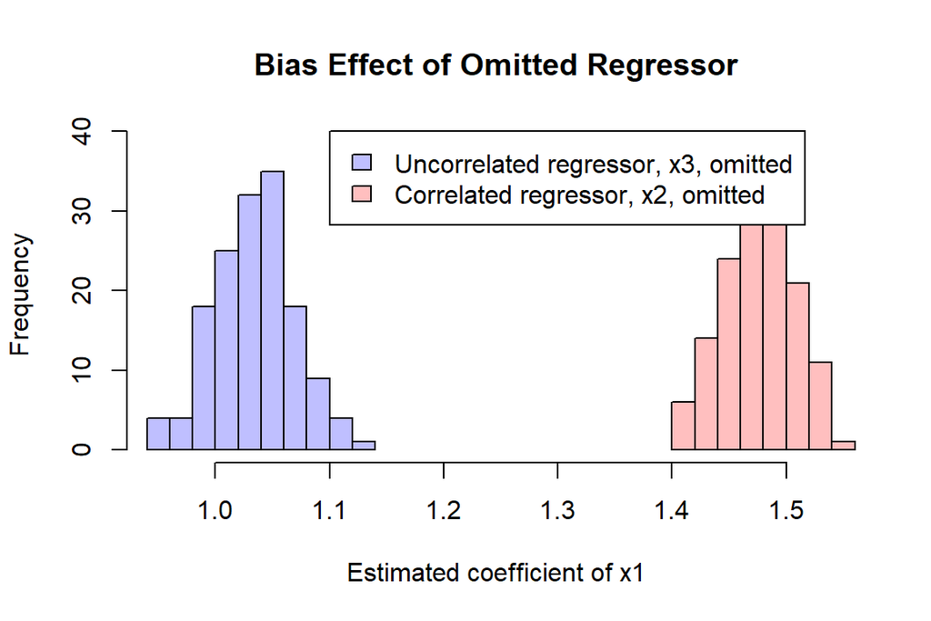

```r
# plot the histogram of beta1 values
p1 <- hist(x1c[1,], plot=FALSE)
p2 <- hist(x1c[2,], plot=FALSE)
yrange <- c(0, max(p1$counts, p2$counts))
plot(p1, col=rgb(0,0,1,1/4), xlim=range(x1c), ylim=yrange, xlab="Estimated coefficient of x1",
    main="Bias Effect of Omitted Regressor")
plot(p2, col=rgb(1,0,0,1/4), xlim=range(x1c), ylim=yrange, add=TRUE)
legend(1.1, 40, c("Uncorrelated regressor, x3, omitted", "Correlated regressor, x2, omitted"),
     fill=c(rgb(0,0,1,1/4), rgb(1,0,0,1/4)))
```

- The first row of the matrix `x1c` contains independent estimates of x1’s coefficient in the case that x3, the regressor uncorrelated with x1, is omitted
- The second row contains estimates of x1’s coefficient when the correlated regressor, x2, is omitted
- Having been warned that omitting a correlated regressor would bias estimates of x1’s coefficient, we would expect the mean estimate of x1c’s second row (omitting correlated regressor) to be farther from 1 than the mean of x1c’s first row (omitting uncorrelated regressor). We do see this.
- The bias is also evident in the histogram of x1’s coefficient. Estimates from the second row are clearly more than two standard deviations from the correct value of 1.

## 15.11 Covariate Model Selection

- automated covariate/predictor selection is difficult
  - the space of models explodes quickly with interactions and polynomial terms
  - **Note**: in the **Practical Machine Learning** class, many modern methods for traversing large model spaces for the purposes of prediction will be covered
- principal components analysis (PCA) or factor analytic models on covariates are often useful for reducing complex covariate spaces
  - find linear combinations of variables that captures the most variation
- good experiment design can often eliminate the need for complex model searches during analyses
  - randomization, stratification can help simply the end models
  - unfortunately, control over the design is *often limited*
- it is also viable to manually explore the covariate space based on understanding of the data
  - use covariate adjustment and multiple models to probe that effect of adding a particular predictor on the model
  - **Note**: this isn’t a terribly systematic or efficient approach, but it tends to teach you a lot about the data through the process
- if the models of interest are nested (i.e. one model is a special case of another with one or more coefficients set to zero) and without lots of parameters differentiating them, it’s fairly possible to use nested likelihood ratio tests (ANOVA) to help find the best model
  - **Analysis of Variance** (ANOVA) works well when adding one or two regressors at a time
    - `anova(fit1, fit2, fit3)` = performs ANOVA or analysis of variance (or deviance) tables for a series of nested linear regressions models
  - **Note**: it is extremely important to get the order of the models correct to ensure the results are sensible
  - an example can be found here
  - Also, we know as the number of regressors in the model $p$ approaches $n$, the model approaches perfect fit for the data. In other words adding random regressors decreases residual squared errors. But we would be mistaken to believe that such decreases are significant. To assess significance, we should take into account that adding regressors **reduces residual degrees of freedom**. Analysis of variance (ANOVA) is a useful way to quantify the significance of additional regressors
- another alternative to search through different models is the **step-wise search** algorithm that repeatedly adds/removes regressors one at a time to find the best model with the least [Akaike Information Criterion (AIC)](http://en.wikipedia.org/wiki/Akaike_information_criterion)
  - `step(lm, k=df)` = performs step wise regression on a given linear model to find and return best linear model
    - `k=log(n)` = specifying the value of `k` as the log of the number of observation will force the step-wise regression model to use Bayesian Information Criterion (BIC) instead of the AIC
    - **Note**: both BIC and AIC penalizes adding parameters to the regression model with an additional penalty term; the penalty is **larger** for BIC than AIC
  - `MASS::stepAIC(lm, k = df)` = more versatile, rigorous implementation of the step wise regression
  - an example can be found here
- My favoriate approach is as follows: Given a coefficient that I’m interested in, I like to use covariate adjustment and multiple models to probe that effect to evaluate it for robustness and to see what other covariates knock it out. This isn’t a terribly systematic approach, but it tends to teach you a lot about the the data as you get your hands dirty.

## 15.12 Example: ANOVA

- Nested model testing in R. In ANOVA the null hypothesis is that the added regressors are not significant
- we will use the `swiss` data set for this example, and compare the following nested models
  1. Fertility vs Agriculture
  2. Fertility vs Agriculture + Examination + Education
  3. Fertility vs Agriculture + Examination + Education + Catholic + Infant.Mortality

```r
# three different regressions that are nested
fit1 <- lm(Fertility ~ Agriculture, data = swiss)
fit3 <- update(fit, Fertility ~ Agriculture + Examination + Education)
fit5 <- update(fit, Fertility ~ Agriculture + Examination + Education + Catholic + Infant.Mortality)
# perform test using ANOVA
anova(fit1, fit3, fit5)
```

```
## Analysis of Variance Table
##
## Model 1: Fertility ~ Agriculture
## Model 2: Fertility ~ Agriculture + Examination + Education
## Model 3: Fertility ~ Agriculture + Examination + Education + Catholic +
##     Infant.Mortality
##   Res.Df    RSS Df Sum of Sq      F    Pr(>F)
## 1     45 6283.1
## 2     43 3180.9  2    3102.2 30.211 8.638e-09 ***
## 3     41 2105.0  2    1075.9 10.477 0.0002111 ***
## ---
## Signif. codes:  0 '***' 0.001 '**' 0.01 '*' 0.05 '.' 0.1 ' ' 1
```

```r
# RSS's are the sum residual sum of squares, eg. for fit3
deviance(fit3)
```

```
## [1] 3180.925
```

- the ANOVA function returns a formatted table with the follow information
  - `Res.Df` = residual degrees of freedom for the models
  - `RSS` = residual sum of squares for the models, measure of fit
  - `Df` = change in degrees of freedom from one model to the next
  - `Sum of Sq` = difference/change in residual sum of squares from one model to the next
  - `F` = F statistic, measures the ratio of two scaled sums of squares divided by their respective degrees of freedom, reflecting different sources of variability
    $$F = \frac{\frac{RSS_1 - RSS_2}{p_2 - p_1}}{\frac{RSS_2}{n-p_2}}$$
    where $p_1$ and $p_2$ = number of parameters (= number of coefficients + 1 intercept, eg. for fit3 p = 4, for fit5 p = 6) in the two models for comparison, and $n$ = number of observations
  - $RSS_1$ and $RSS_2$ have mean zero hence are centrally chi-squared provided the residuals themselves are normally distributed
  - `Pr(>F)` = p-value for the F statistic to indicate whether the change in model is significant or not
  - Rejection is based on a right-tailed F test, `Pr(>F)`, applied to an F value
- from the above result, we can see that both going from first to second, and second to third models result in significant reductions in RSS and *better model fits*
- Furthermore, the null hypothesis tests are rejected at the 0.001 level, so at least one of the two additional regressors is significant (fit1 to fit2, as well as fit2 to fit3).
- We are confident that fit3 is significantly better than fit1 (test is signficant), with one caveat: analysis of variance is sensitive to its **assumption that model residuals are approximately normal**. If they are not, we could get a small p-value for that reason. It is thus worth testing residuals for normality. The Shapiro-Wilk test is quick and easy in R (Normality is its null hypothesis)

```r
shapiro.test(fit3$residuals)
```

```
##
##  Shapiro-Wilk normality test
##
## data:  fit3$residuals
## W = 0.97276, p-value = 0.336
```

```r
shapiro.test(fit5$residuals)
```

```
##
##  Shapiro-Wilk normality test
##
## data:  fit5$residuals
## W = 0.98892, p-value = 0.9318
```

- The Shapiro-Wilk test fails to reject the null (normality), supporting confidence in our analysis of variance

## 15.13 Example: Step-wise Model Search

- we will use the `mtcars` data set for this example, and perform step-wise regression/model selection algorithm on the following initial model
  - Miles Per Gallon vs Number of Cylinder + Displacement + Gross Horse Power + Rear Axle Ratio + Weight

```r
# load the mtcars data starting regression model
data(mtcars); fit <- lm(mpg ~ cyl + disp + hp + drat + wt, data = mtcars)
# step-wise search using BIC
step(fit, k = log(nrow(mtcars)))
```

```
## Start:  AIC=73.75
## mpg ~ cyl + disp + hp + drat + wt
##
##        Df Sum of Sq    RSS    AIC
## - drat  1     3.018 170.44 70.854
## - disp  1     6.949 174.38 71.584
## - cyl   1    15.411 182.84 73.100
## <none>              167.43 73.748
## - hp    1    21.066 188.49 74.075
## - wt    1    77.476 244.90 82.453
##
## Step:  AIC=70.85
## mpg ~ cyl + disp + hp + wt
##
##        Df Sum of Sq    RSS    AIC
## - disp  1     6.176 176.62 68.528
## - hp    1    18.048 188.49 70.609
## <none>              170.44 70.854
## - cyl   1    24.546 194.99 71.694
## - wt    1    90.925 261.37 81.069
##
## Step:  AIC=68.53
## mpg ~ cyl + hp + wt
##
##        Df Sum of Sq    RSS    AIC
## - hp    1    14.551 191.17 67.595
## - cyl   1    18.427 195.05 68.237
## <none>              176.62 68.528
## - wt    1   115.354 291.98 81.147
##
## Step:  AIC=67.6
## mpg ~ cyl + wt
##
##        Df Sum of Sq    RSS    AIC
## <none>              191.17 67.595
## - cyl   1     87.15 278.32 76.149
## - wt    1    117.16 308.33 79.426
```

```
##
## Call:
## lm(formula = mpg ~ cyl + wt, data = mtcars)
##
## Coefficients:
## (Intercept)          cyl           wt
##      39.686       -1.508       -3.191
```

- as we can see from above, the best model that captures most of the variability in the data is simply `mpg ~ cyl + wt`

# 16 General Linear Models Overview

- **Intro**: Generalized linear models (GLMs) were a great advance in statistical modeling. The original manuscript with the GLM framework was from Nelder and Wedderburn in 1972 in the Journal of the Royal Statistical Society. The McCullagh and Nelder book is the famous standard treatise on the subject.  
  Recall linear models. Linear models are the most useful applied statistical technique. However, they are not without their limitations. Additive response models don’t make much sense if the response is discrete, or strictly positive. Additive error models often don’t make sense, for example, if the outcome has to be positive. Transformations, such as taking a cube root of a count outcome, are often hard to interpret. In addition, there’s value in modeling the data on the scale that it was collected. Particularly interpretable transformations, natural logarithms in specific, aren’t applicable for negative or zero values.  
  The generalized linear model is a family of models that includes linear models. By extending the family, it handles many of the issues with linear models, but at the expense of some complexity and loss of some of the mathematical tidiness. A GLM involves three components: (1) An exponential family model for the response, (2) A systematic component via a linear predictor, and (3) A link function that connects the means of the response to the linear predictor.  
  The three most famous cases of GLMs are: linear models, binomial and binary regression and Poisson regression. We’ll go through the GLM model specification and likelihood for all three. For linear models, we’ve developed them previously. The next two modules will be devoted to binomial and Poisson regression. We’ll only focus on the most popular and useful link functions.
- limitations of linear models:
  - response can be discrete (i.e. 0, 1, etc.) or strictly positive $\rightarrow$ linear response models don’t make much sense
  - if outcome must be positive, Gaussian errors ($\pm$ errors) don’t make sense as negative outcomes are possible
  - transformations on predictors (log + 1) are often hard to interpret
    - modeling the data on the scale that it was collected is most ideal
    - particularly interpretable transformations, *natural logarithms* specifically, aren’t applicable for negative or zero values
- **general linear models** = introduced in 1972 RSSB paper by Nelder and Wedderburn and has *3* parts
  1. exponential family model for response/outcome (i.e. Gaussian, Bernoulli distribution)
  2. systematic component for linear predictor $\rightarrow$ incorporates the information about the independent variables into the model
     - denoted by $\eta = X \beta$ where $X$ is a matrix of independent variables/predictors and $\beta$ is the coefficients
  3. link function that connects means of the outcome/distribution to linear predictor
     - the relationship is defined as $\eta = g(\mu)$, or the linear predictor $\eta$ is a function of the mean of the distribution $\mu$

## 16.2 Logistic Regression

- *exponential family distribution*: binomial/Bernoulli distribution assumed, that is $Y_i \sim Bernoulli(\mu_i)$ where the probability of success is $\mu_i$
  - due to the properties of the binomial/Bernoulli distribution, $E[Y_i] = \mu_i$ where $0 \leq \mu_i \leq 1$
- *linear predictor*: $\eta_i = \sum_{k=1}^p X_{ik} \beta_k$
- *link function* : $g(\mu) = \eta = \log\left(\frac{\mu}{1 - \mu}\right)$
  - **odds** for success for a binomial/Bernoulli distribution is defined as
    $$\mbox{odds} = \frac{p}{1-p}$$
  - **logit** is defined as
    $$\log(\mbox{odds}) = \log \frac{\mu}{1-\mu}$$
    - **Note**: the $\log$ here is the **natural** log
    - **Note**: We’re transforming the mean of the distribution, and not the Ys themselves
  - **inverse logit** is defined as
    $$\mu_i = \frac{\exp(\eta_i)}{1 + \exp(\eta_i)}$$
  - complement of inverse logit is
    $$1 - \mu_i = \frac{1}{1 + \exp(\eta_i)}$$
- **result**: the likelihood model
  $$\begin{aligned}
  L(\beta) & = \prod_{i=1}^n \mu_i^{y_i} (1 - \mu_i)^{1-y_i} \\
  (plug~in~\mu_i~and~1 - \mu_i~from~above)& = \prod_{i=1}^n \left(\frac{\exp(\eta_i)}{1 + \exp(\eta_i)}\right)^{y_i} \left(\frac{1}{1 + \exp(\eta_i)}\right)^{1-y_i}\\
  (multiply~2^{nd}~term~by~\frac{exp(\eta_i)}{exp(\eta_i)})& = \prod_{i=1}^n \left(\frac{\exp(\eta_i)}{1 + \exp(\eta_i)}\right)^{y_i} \left(\frac{\exp(\eta_i)}{1 + \exp(\eta_i)}\right)^{1-y_i} \left(\frac{1}{\exp(\eta_i)}\right)^{1-y_i}\\
  (simplify) & = \prod_{i=1}^n \left(\frac{\exp(\eta_i)}{1 + \exp(\eta_i)}\right) \left(\frac{1}{\exp(\eta_i)}\right)^{1-y_i}\\
  (simplify) & = \prod_{i=1}^n \left(\frac{\exp(\eta_i)}{1 + \exp(\eta_i)}\right) \exp(\eta_i)^{y_i-1}\\
  (simplify) & = \prod_{i=1}^n \frac{\exp(\eta_i)^{y_i}}{1 + \exp(\eta_i)} \\
  (change~form~of~numerator) & = \exp\left(\sum_{i=1}^n y_i \eta_i \right)\prod_{i=1}^n \frac{1}{1 + \exp(\eta_i)}\\
  (substitute~\eta_i) \Rightarrow L(\beta) & = \exp\left(\sum_{i=1}^n y_i \big(\sum_{k=1}^p X_{ik} \beta_k \big) \right)\prod_{i=1}^n \frac{1}{1 + \exp\big(\sum_{k=1}^p X_{ik} \beta_k \big)}\\
  \end{aligned}$$
  - maximizing the likelihood $L(\beta)$ (solving for $\frac{\partial L}{\partial \beta} = 0)$ would return a set of optimized coefficients $\beta$ that will fit the data

## 16.3 Poisson Regression

- *exponential family distribution*: Poisson distribution assumed, that is $Y_i \sim Poisson(\mu_i)$ so that $E[Y_i] = \mu_i$ where $0\leq \mu_i$
- *linear predictor*: $\eta_i = \sum_{k=1}^p X_{ik} \beta_k$
- *link function* : $g(\mu) = \eta = \log(\mu)$
  - **Note**: the $\log$ here is the **natural** log
  - since $e^x$ is the inverse of $\log(x)$, then $\eta_i = \log(\mu_i)$ can be transformed into $\mu_i = e^{\eta_i}$
- **result**: the likelihood model
  $$\begin{aligned}
  L(\beta) & = \prod_{i=1}^n (y_i !)^{-1} \mu_i^{y_i}e^{-\mu_i}\\
  (substitute~\mu_i = e^{\eta_i}) & = \prod_{i=1}^n \frac{(e^{\eta_i})^{y_i}}{y_i! e^{e^{\eta_i}}}\\
  (transform) &= \prod_{i=1}^n \frac{\exp(\eta_i y_i)}{y_i! \exp(e^{\eta_i})}\\
  (taking~\log~of~both~sides)~\mathcal{L}(\beta) & = \sum_{i=1}^n \eta_i y_i - \sum_{i=1}^n e^{\eta_i} - \sum_{i=1}^n log(y_i!) \\
  (since~y_i~is~given,~we~can~ignore~\log y_i!)~\mathcal{L}(\beta) & \propto \sum_{i=1}^n \eta_i y_i - \sum_{i=1}^n e^{\eta_i}\\
  (substitute~\eta_i= \sum_{k=1}^p X_{ik} \beta_k) \Rightarrow \mathcal{L}(\beta) & \propto \sum_{i=1}^n y_i \left(\sum_{k=1}^p X_{ik}\beta_k\right) - \sum_{i=1}^n \exp \left(\sum_{k=1}^p X_{ik} \beta_k \right) \\
  \end{aligned}$$
  - maximizing the log likelihood $\mathcal{L}(beta)$ (solving for $\frac{\partial \mathcal{L}}{\partial \beta} = 0)$ would return a set of optimized coefficients $\beta$ that will fit the data

## 16.4 Variances and Quasi-Likelihoods

- in each of the linear/Bernoulli/Poisson cases, the *only* term in the likelihood functions that depend on the *data* is
  $$\sum_{i=1}^n y_i \eta_i =\sum_{i=1}^n y_i\sum_{k=1}^p X_{ik} \beta_k = \sum_{k=1}^p \beta_k\sum_{i=1}^n X_{ik} y_i$$
- this means that we don’t need need all of the data collected to maximize the likelihoods/find the coefficients $\beta$, but *only* need $\sum_{i=1}^n X_{ik} y_i$
  - **Note**: this simplification is a consequence of choosing “**canonical**” link functions, $g(\mu)$, to be in specific forms
- [Derivation needed] all models achieve their *maximum* at the root of the **normal equations**
  $$\sum_{i=1}^n \frac{(Y_i - \mu_i)}{Var(Y_i)}W_i = 0$$
  where $W_i = \frac{\partial g^{-1}(\mu_i)}{\mu_i}$ or the derivative of the inverse of the link function
  - **Note**: this is similar to deriving the least square equation where the middle term must be set to 0 to find the solution (see Derivation for $\beta$)
  - **Note**: $\mu_i = g^{-1}(\eta_i) =g^{-1}\left(\sum_{k=1}^p X_{ik} \beta_k\right)$, the normal functions are really functions of $\beta$
- the variance, $Var(Y_i)$, is defined as
  - *linear model*: $Var(Y_i) = \sigma^2$, where $\sigma$ is constant
  - *binomial model*: $Var(Y_i) = \mu_i (1 - \mu_i)$
  - *Poisson model*: $Var(Y_i) = \mu_i$
- for binomial and Poisson models, there are *strict relationships* between the mean and variance that can be easily tested from the data:
  - binomial: mean = $\mu_i$, variance = $\mu_i (1 - \mu_i)$
  - Poisson: mean = $\mu_i$, variance = $\mu_i$
- it is often relevant to have a *more flexible* variance model (i.e. data doesn’t follow binomial/Poisson distributions exactly but are approximated; eg. assuming poisson, the mean and variance are not equal, but in theory should be equal to $\mu_i$), even if it doesn’t correspond to an actual likelihood, so we can add an extra parameter, $\phi$, to the normal equations to form **quasi-likelihood normal equations**
  $$binomial:~\sum_{i=1}^n \frac{(Y_i - \mu_i)}{\phi \mu_i (1 - \mu_i ) } W_i=0 \\
  Poisson:~\sum_{i=1}^n \frac{(Y_i - \mu_i)}{\phi \mu_i} W_i=0$$
  where $W_i = \frac{\partial g^{-1}(\mu_i)}{\mu_i}$ or the derivative of the inverse of the link function
  - for R function `glm()`, its possible to specify for the model to solve using quasi-likelihood normal equations instead of normal equations through the parameter `family = quasi-binomial` and `family = quasi-poisson` respectively
  - **Note**: the quasi-likelihoods models generally same properties as normal GLM

## 16.5 Solving for Normal and Quasi-Likelihood Normal Equations

- normal equations have to be solved *iteratively*
  - the results are $\hat \beta_k$, estimated coefficients for the predictors
  - for quasi-likelihood normal equations, $\hat \phi$ will be part of the results as well
  - in R, [Newton/Raphson’s algorithm](http://en.wikipedia.org/wiki/Newton%27s_method) is used to solve the equations
  - **Note**: many of the ideas, interpretation, and conclusions derived from simple linear models are applicable to GLMs
- **predicted linear predictor responses** are defined as
  $$\hat \eta = \sum_{k=1}^p X_k \hat \beta_k$$
- **predicted mean responses** can be solved from
  $$\hat \mu = g^{-1}(\hat \eta)$$
- **coefficients** are interpreted as the *expected change in the link function* of the expected response *per unit change* in $X_k$ holding other regressors constant, or
  $$\beta_k = g(E[Y | X_k = x_k + 1, X_{\sim k} = x_{\sim k}]) - g(E[Y | X_k = x_k, X_{\sim k}=x_{\sim k}])$$
- **Note**: responses and coefficients are on different scale (because data was transformed). Especially for coefficients the interpretation is done on the scale of the linear predictor, in binomial cases on the scale of logent, for Poisson cases on the scale of the log mean.
- *asymptotics* are used for inference of results (see *Statistical Inference* course), that is all of these results are based on asymptotics which means that they require larger sample sizes. So if you have a GLM setting with a very small sample size, then it’s possible that things like the p-values aren’t really applicable.

# 17 General Linear Models - Binary Models

- **Intro**: Binary GLMs come from trying to model outcomes that can take only two values. Some examples include: survival or not at the end of a study, winning versus losing of a team and success versus failure of a treatment or product. Often these outcomes are called Bernoulli outcomes, from the Bernoulli distribution named after the famous probabilist and mathematician.  
  If we happen to have several exchangeable binary outcomes for the same level of covariate values, then that is binomial data and we can aggregate the 0’s and 1’s into the count of 1’s. As an example, imagine if we sprayed insect pests with 4 different pesticides and counted whether they died or not. Then for each spray, we could summarize the data with the count of dead and total number that were sprayed and treat the data as binomial rather than Bernoulli.
- **Bernoulli/binary** models are frequently used to model outcomes that have two values
  - alive vs dead
  - win vs loss
  - success vs failure
  - disease vs healthy
- **binomial outcomes** = collection of exchangeable binary outcomes (i.e. flipping coins repeatedly) for the same covariate data
  - in other words, we are interested in the count of predicted $1$s vs $0$s rather individual outcomes of $1$ or $0$

## 17.1 Odds

- [**odds**](http://en.wikipedia.org/wiki/Odds_ratio) are useful in constructing logistic regression models and fairly easy to interpret
  - imagine flipping a coin with success probability $p$
    - if heads, you win $X$
    - if tails, you lose $Y$
  - how should $X$ and $Y$ be set so that the game is *fair*?
    $$E[earnings]= X p - Y (1 - p) = 0 \Rightarrow \frac{Y}{X} = \frac{p}{1 - p}$$
  - odds can be interpreted as “How much should you be willing to pay for a $p$ probability of winning a dollar?”
    - if $p > 0.5$, you have to pay more if you lose than you get if you win
    - if $p < 0.5$, you have to pay less if you lose than you get if you win
- odds are **NOT** probabilities
- odds ratio of 1 = no difference in odds or 50% - 50%
  - $p = 0.5 \Rightarrow odds = \frac{0.5}{1-0.5} = 1$
- log odds ratio of 0 = no difference in odds
  - $p = 0.5 \Rightarrow log odds = \log\left(\frac{0.5}{1-0.5}\right) = \log(1) = 0$
- odds ratio < 0.5 or > 2 commonly a “moderate effect”
- **relative risk** = ratios of probabilities instead of odds, and are often easier to interpret but harder to estimate
  $$\frac{Pr(W_i | S_i = 10)}{Pr(W_i | S_i = 0)}$$
  - **Note**: relative risks often have **boundary problems** as the range of $\log(p)$ is $(-\infty,~0]$ where as the range of logit $\frac{p}{1-p}$ is $(-\infty,\infty)$
  - for small probabilities Relative Risk $\approx$ Odds Ratio but **they are not the same**!
- More on [Odds Ratio](https://en.wikipedia.org/wiki/Odds_ratio)

## 17.2 Example - Baltimore Ravens Win vs Loss

- the data for this example can be found [here](https://dl.dropboxusercontent.com/u/7710864/data/ravensData.rda)
  - the data contains the records 20 games for Baltimore Ravens, a professional American Football team
  - there are 4 columns
    - `ravenWinNum` = 1 for Raven win, 0 for Raven loss
    - `ravenWin` = W for Raven win, L for Raven loss
    - `ravenScore` = score of the Raven team during the match
    - `opponentScore` = score of the Raven team during the match

```r
# load the data
load("./data/ravensData.rda")
ravensData
```

```
##    ravenWinNum ravenWin ravenScore opponentScore
## 1            1        W         24             9
## 2            1        W         38            35
## 3            1        W         28            13
## 4            1        W         34            31
## 5            1        W         44            13
## 6            0        L         23            24
## 7            1        W         31            30
## 8            1        W         23            16
## 9            1        W          9             6
## 10           1        W         31            29
## 11           0        L         13            43
## 12           1        W         25            15
## 13           1        W         55            20
## 14           1        W         13            10
## 15           1        W         16            13
## 16           0        L         20            23
## 17           0        L         28            31
## 18           0        L         17            34
## 19           1        W         33            14
## 20           0        L         17            23
```

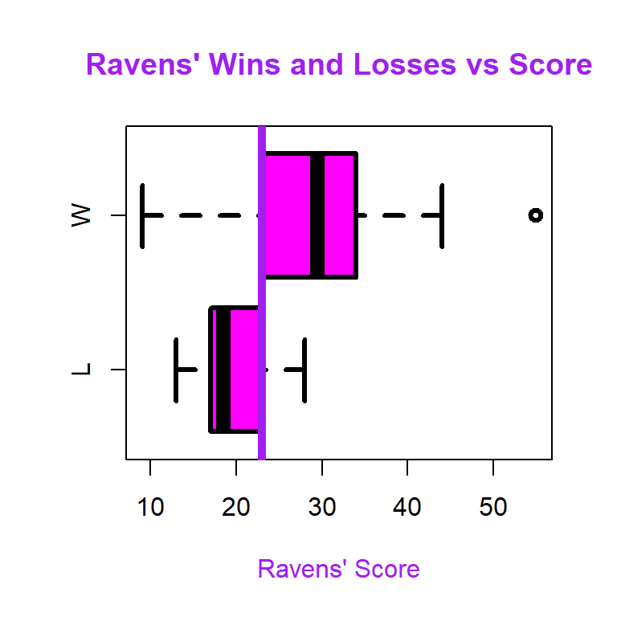

```r
# boxplot of wins and losses
boxplot(ravenScore ~ ravenWin, ravensData, col=0x96, lwd=3, horizontal=TRUE,
        col.lab="purple", col.main="purple", xlab="Ravens' Score",
        main="Ravens' Wins and Losses vs Score")
abline(v=23, lwd=5, col="purple")
```

- We see from the boxplot that in fact, about 3/4 of their losses are at or below a score of 23 (purple vertical line) and about 3/4 of their wins are at or above it. (Remember that the purple boxes represent 50% of the samples, and the “T’s” 25%.)
- There were 9 games in which the Ravens scored 23 points or less. They won 4 of these games, so we might guess their probability of winning, given that they score 23 points or less, is about 1/2.
- There were 11 games in which the Ravens scored 24 points or more. They won all but one of these.
- We see a fairly rapid transition in the Ravens’ win/loss record between 23 and 28 points. At 23 points and below they win about half their games, between 24 and 28 points they win 3 of 4, and above 28 points they win them all. From this, we get a very crude idea of the correspondence between points scored and the probability of a win. We get an S shaped curve.

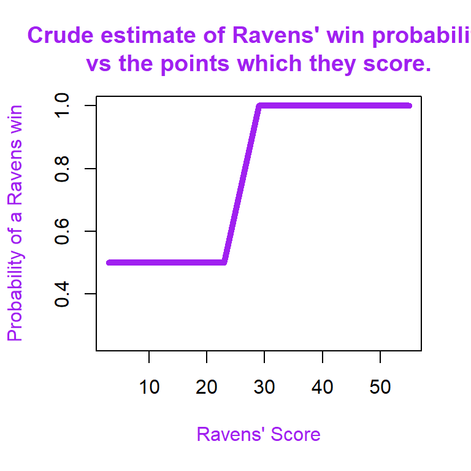

```r
# plot probabilities from the data
plot(c(3,23,29,55), c(0.5, 0.5, 1.0, 1.0), type='l', lwd=5, col="purple", col.lab="purple", ylim=c(0.25,1),
     xlab="Ravens' Score", ylab="Probability of a Ravens win", col.main="purple",
     main="Crude estimate of Ravens' win probability\nvs the points which they score.")
```

- Of course, we would expect a real curve to be smoother. We would not, for instance, expect the Ravens to win half the games in which they scored zero points, nor to win all the games in which they scored more than 28. A generalized linear model which has these properties supposes that the log odds of a win depend linearly on the score. That is, $\log(p/(1-p)) = \beta_0 + \beta_1 \times \text{score}$. The link function, $\log(p/(1-p))$, is called the logit, and the process of finding the best $\beta_0$ and $\beta_1$, is called logistic regression. The “best” $\beta_0$ and $\beta_1$ are those which maximize the likelihood of the actual win/loss record. Based on the score of a game, $\beta_0$ and $\beta_1$ give us a log odds, which we can convert to a probability, $p$, of a win. We would like $p$ to be high for the scores of winning games, and low for the scores of losses. Before we discuss the logisitic regression, we see how the simple linear regression would perform.

## 17.3 Example - Simple Linear Regression

- **simple linear regression** can be used model win vs loss for the Ravens
  $$W_i = \beta_0 + \beta_1 S_i + \epsilon_i$$
  - $W_i$ = binary outcome, 1 if a Ravens win, 0 if not
  - $S_i$ = number of points Ravens scored
  - $\beta_0$ = probability of a Ravens win if they score 0 points
  - $\beta_1$ = increase in probability of a Ravens win for each additional point
  - $\epsilon_i$ = residual variation, error
- the expected value for the model is defined as
  $$E[W_i | S_i, \beta_0, \beta_1] = \beta_0 + \beta_1 S_i$$
- however, the model wouldn’t work well as the predicted results *won’t* be 0 vs 1
  - the error term, $\epsilon_i$, is assumed to be continuous and normally distributed, meaning that the prediction will likely be a decimal
  - therefore, this is *not* a good assumption for the model

```r
# perform linear regression
summary(lm(ravenWinNum ~ ravenScore, data = ravensData))
```

```
##
## Call:
## lm(formula = ravenWinNum ~ ravenScore, data = ravensData)
##
## Residuals:
##     Min      1Q  Median      3Q     Max
## -0.7302 -0.5076  0.1824  0.3215  0.5719
##
## Coefficients:
##             Estimate Std. Error t value Pr(>|t|)
## (Intercept) 0.285032   0.256643   1.111   0.2814
## ravenScore  0.015899   0.009059   1.755   0.0963 .
## ---
## Signif. codes:  0 '***' 0.001 '**' 0.01 '*' 0.05 '.' 0.1 ' ' 1
##
## Residual standard error: 0.4464 on 18 degrees of freedom
## Multiple R-squared:  0.1461, Adjusted R-squared:  0.09868
## F-statistic:  3.08 on 1 and 18 DF,  p-value: 0.09625
```

- as expected, the model produces a poor fit for the data ($R^2_{adj} =$ 0.0987)
- adding a threshold to the predicted outcome (i.e. if $\hat W_i < 0.5, \hat W_i = 0$) and using the model to predict the results would be *viable*
  - however, the coefficients for the model are *not very interpretable*

## 17.4 Example - Logistic Regression

- **Binary Outcome (0/1)** $W_i$
- Model the **probability** of Ravens win, defined as
  $$Pr(W_i | S_i, \beta_0, \beta_1)$$
- **odds** is defined as
  $$\frac{Pr(W_i | S_i, \beta_0, \beta_1 )}{1-Pr(W_i | S_i, \beta_0, \beta_1)}$$
  which can take values from 0 to $\infty$
- log odds or **logit** is defined as
  $$\log\left(\frac{Pr(W_i | S_i, \beta_0, \beta_1 )}{1-Pr(W_i | S_i, \beta_0, \beta_1)}\right)$$
  which can take values from $-\infty$ to $\infty$
- we can use the link function and linear predictors to construct the **logistic regression** model
  $$\begin{aligned}
  g(\mu_i) & = \log \left(\frac{\mu_i}{1 - \mu_i} \right) = \eta_i\\
  (substitute~\mu_i = Pr(W_i | S_i, \beta_0, \beta_1))~g(\mu_i) & = \log\left(\frac{Pr(W_i | S_i, \beta_0, \beta_1)}{1-Pr(W_i | S_i, \beta_0, \beta_1)}\right) = \eta_i \\
  (substitute~\eta_i=\beta_0 + \beta_1 S_i) \Rightarrow ~g(\mu_i) & = \log\left(\frac{Pr(W_i | S_i, \beta_0, \beta_1)}{1-Pr(W_i | S_i, \beta_0, \beta_1)}\right) = \beta_0 + \beta_1 S_i\\
  \end{aligned}$$
  which can also be written as
  $$Pr(W_i | S_i, \beta_0, \beta_1 ) = \frac{\exp(\beta_0 + \beta_1 S_i)}{1 + \exp(\beta_0 + \beta_1 S_i)}$$
- for the model
  $$\log\left(\frac{Pr(W_i | S_i, \beta_0, \beta_1)}{1-Pr(W_i | S_i, \beta_0, \beta_1)}\right) = \beta_0 + \beta_1 S_i$$
  - $\beta_0$ = log odds of a Ravens win if they score zero points
  - $\beta_1$ = log odds ratio of win probability for each point scored (compared to zero points)
    $$\beta_1 = \log\left(odds(S_i = S_i+1)\right) - \log\left(odds(S_i = S_i)\right) = \log\left(\frac{odds(S_i = S_i+1)}{odds(S_i = S_i)} \right)$$
  - $\exp(\beta_1)$ = odds ratio of win probability for each point scored (compared to zero points)
    $$\exp(\beta_1) = \frac{odds(S_i = S_i+1)}{odds(S_i = S_i)}$$
- we can leverage the `manipulate` function, vary $\beta_0$ and $\beta_1$ to fit logistic regression curves for simulated data

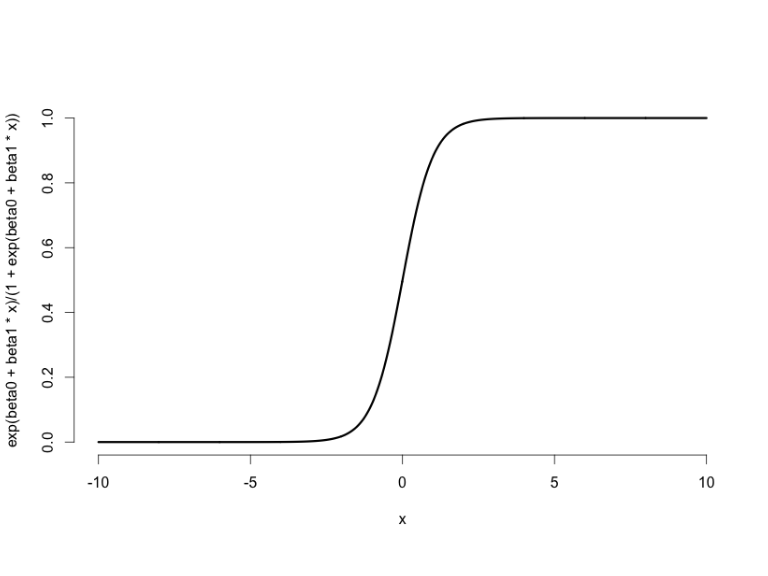

```r
# set x values for the points to be plotted
x <- seq(-10, 10, length = 1000)
# "library(manipulate)" is needed to use the manipulate function
manipulate(
    # plot the logistic regression curve
    plot(x, exp(beta0 + beta1 * x) / (1 + exp(beta0 + beta1 * x)),
         type = "l", lwd = 3, frame = FALSE),
    # slider for beta1
    beta1 = slider(-2, 2, step = .1, initial = 2),
    # slider for beta0
    beta0 = slider(-2, 2, step = .1, initial = 0)
    )
```

- we can use the `glm(outcome ~ predictor, family = "binomial")` to fit a logistic regression to the data

```r
# run logistic regression on data
logRegRavens <- glm(ravenWinNum ~ ravenScore, data = ravensData, family="binomial")
# print summary
summary(logRegRavens)
```

```
##
## Call:
## glm(formula = ravenWinNum ~ ravenScore, family = "binomial",
##     data = ravensData)
##
## Deviance Residuals:
##     Min       1Q   Median       3Q      Max
## -1.7575  -1.0999   0.5305   0.8060   1.4947
##
## Coefficients:
##             Estimate Std. Error z value Pr(>|z|)
## (Intercept) -1.68001    1.55412  -1.081     0.28
## ravenScore   0.10658    0.06674   1.597     0.11
##
## (Dispersion parameter for binomial family taken to be 1)
##
##     Null deviance: 24.435  on 19  degrees of freedom
## Residual deviance: 20.895  on 18  degrees of freedom
## AIC: 24.895
##
## Number of Fisher Scoring iterations: 5
```

- as we can see above, the coefficients $\beta_0$ and $\beta_1$ are -1.68, 0.107, which are interpreted to be the log odds ratios
- we can convert the log ratios as well as the log confidence intervals to ratios and confidence intervals (in the same units as the data)

```r
# take e^coefs to find the ratios
exp(logRegRavens$coeff)
```

```
## (Intercept)  ravenScore
##   0.1863724   1.1124694
```

```r
# take e^log confidence interval to find the confidence intervals
exp(confint(logRegRavens))
```

```
##                   2.5 %   97.5 %
## (Intercept) 0.005674966 3.106384
## ravenScore  0.996229662 1.303304
```

- **Note**: $\exp(x) \approx 1 + x$ for small values (close to 0) of x, this can be a quick way to estimate the coefficients
- we can interpret the slope, $\beta_1$ as 11.247 % increase in the odds (careful: not probabilities) of winning for every point scored
- we can interpret the intercept $\beta_0$ as 0.186 is the odds for Ravens winning if they scored 0 points
  - **Note**: similar to the intercept of a simple linear regression model, the intercept should be interpreted carefully as it is an extrapolated value from the model and may not hold practical meaning
- Regarding the coefficients on the logit scale, for example for the score variable $\beta_1$, you want to see whether or not the coefficient is close to zero or not. On the exponentiated scale you want to see whether or not it’s close to one. Because that will give us the standard error and a Z value and the P value
  - From the confidence interval for $\beta_1$ we see the lower bound is below zero (suggesting a decrease in winning probability per 1 point increase in score), therefore it turns out not to be significant (due to a large standard error).
- to calculate specific probability of winning for a given number of points
  $$Pr(W_i | S_i, \hat \beta_0, \hat \beta_1) = \frac{\exp(\hat \beta_0 + \hat \beta_1 S_i)}{1 + \exp(\hat \beta_0 + \hat \beta_1 S_i)}$$
- the resulting logistic regression curve can be seen below, that is, the predictive responses put back on the **probability scale**

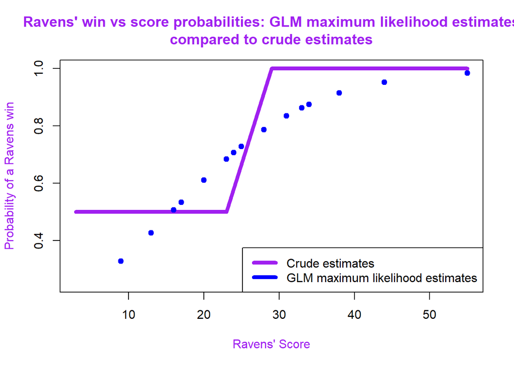

```r
# plot probabilities from the data
plot(c(3,23,29,55), c(0.5, 0.5, 1.0, 1.0), type='l', lwd=5, col="purple", col.lab="purple", ylim=c(0.25,1),
     xlab="Ravens' Score", ylab="Probability of a Ravens win", col.main="purple",
     main="Ravens' win vs score probabilities: GLM maximum likelihood estimates\ncompared to crude estimates")
# plot the logistic regression
points(ravensData$ravenScore,logRegRavens$fitted,pch=19,col="blue",xlab="Score",ylab="Prob Ravens Win")
# add legend
legend('bottomright', c("Crude estimates", "GLM maximum likelihood estimates"), lwd=5, lty=1,
                        col=c("purple", "blue"))
```

- The probabilities estimated by logistic regression using glm() are represented by the blue dots. It is more reasonable than our crude estimate in several respects: It increases smoothly with score, it estimates that 15 points give the Ravens a 50% chance of winning, that 28 points give them an 80% chance, and that 55 points make a win very likely (98%) but not absolutely certain.
- Since we don’t have data below a score of 9, we can use R’s `predict()` function to see the model’s estimates for lower scores. Since this gives us log odds, we will have to convert to probabilities.

```r
# calculate log odds
logodds<-predict(logRegRavens, data.frame(ravenScore=c(0,3,6)))
# convert to probabilities
exp(logodds)/(1+exp(logodds))
```

```
##         1         2         3
## 0.1570943 0.2041977 0.2610505
```

## 17.5 Example - ANOVA for Logistic Regression

- ANOVA can be performed on a single logistic regression, in which it will analyze the change in variances with addition of parameters in the model, or multiple nested logistic regression (similar to linear models)

```r
# perform analysis of variance
anova(logRegRavens,test="Chisq")
```

```
## Analysis of Deviance Table
##
## Model: binomial, link: logit
##
## Response: ravenWinNum
##
## Terms added sequentially (first to last)
##
##
##            Df Deviance Resid. Df Resid. Dev Pr(>Chi)
## NULL                          19     24.435
## ravenScore  1   3.5398        18     20.895  0.05991 .
## ---
## Signif. codes:  0 '***' 0.001 '**' 0.01 '*' 0.05 '.' 0.1 ' ' 1
```

- ANOVA returns information about the model, link function, response, as well as analysis of variance for adding terms
  - `Df` = change in degrees of freedom
    - the value 1 refers to adding the `ravenScore` parameter (slope)
  - `Deviance` = measure of goodness of model fit compare to the previous model
  - `Resid. Dev` = residual deviance for current model
  - `Pr(>Chi)` = used to evaluate the significance of the added parameter
- in this case, the `Deviance` value of 3.54 is actually the difference between the deviance of our model, which includes a slope, and that of a model which includes only an intercept.
- the corresponding p-value from the Chi Squared distribution is 0.06
  - The null hypothesis is that the coefficient of ravenScore is zero. Given the p-value we fail to reject the null. In other words, the score variable adds very little to a model which just guesses.
  - **Note**: Chi Squared distribution with 1 degree of freedom (2 parameters minus 1 parameter, or equivalently 19-18) is simply the squared of normal distribution, so z statistic of 2 corresponds to 95% for normal distribution indicates that deviance of 4 corresponds to approximately 5% in the Chi Squared distribution (which is what our result shows)

## 17.6 Further resources

- [Wikipedia on Logistic Regression](http://en.wikipedia.org/wiki/Logistic_regression)
- [Logistic regression and GLMs in R](http://data.princeton.edu/R/glms.html)
- Brian Caffo’s lecture notes on: [Simpson’s Paradox](http://ocw.jhsph.edu/courses/MethodsInBiostatisticsII/PDFs/lecture23.pdf), [Retrospective Case-control Studies](http://ocw.jhsph.edu/courses/MethodsInBiostatisticsII/PDFs/lecture24.pdf)
- [Open Intro Chapter on Logistic Regression](https://www.openintro.org/index.php)

# 18 General Linear Models - Poisson Models

- **Intro**: Many data take the form of unbounded count data. For example, consider the number of calls to a call center or the number of flu cases in an area or the number of hits to a web site.  
  In some cases the counts are clearly bounded. However, modeling the counts as unbounded is often done when the upper limit is not known or very large relative to the number of events.  
  If the upper bound is known, the techniques weâ€™re discussing can be used to model the proportion or rate. The starting point for most count analysis is the the Poisson distribution.
- **Poisson distribution** is a useful model for counts and rates
  - **rate** = count per unit of time
  - linear regression with transformation is an alternative
- count data examples
  - calls to a call center
  - number of flu cases in an area
  - number of cars that cross a bridge
- rate data examples
  - percent of children passing a test
  - percent of hits to a website from a country
  - radioactive decay
- Poisson model examples
  - modeling web traffic hits incidence rates
  - approximating binomial probabilities with small $p$ and large $n$
  - analyzing contingency table data (tabulated counts for categorical variables)

## 18.1 Properties of Poisson Distribution

- a set of data $X$ is said to follow the Poisson distribution, or $X \sim Poisson(t\lambda)$, if
  $$P(X = x) = \frac{(t\lambda)^x e^{-t\lambda}}{x!}$$
  where $x = 0, 1, \ldots$
  - $\lambda$ = rate or expected count per unit time
  - $t$ = monitoring time
- **mean** of Poisson distribution is $E[X] = t\lambda$, thus $E[X / t] = \lambda$
- **variance** of the Poisson is $Var(X) = t\lambda = \mu (mean)$
  - **Note**: Poisson approaches a Gaussian/normal distribution as $t\lambda$ gets large
- below are the Poisson distributions for various values of $\lambda$

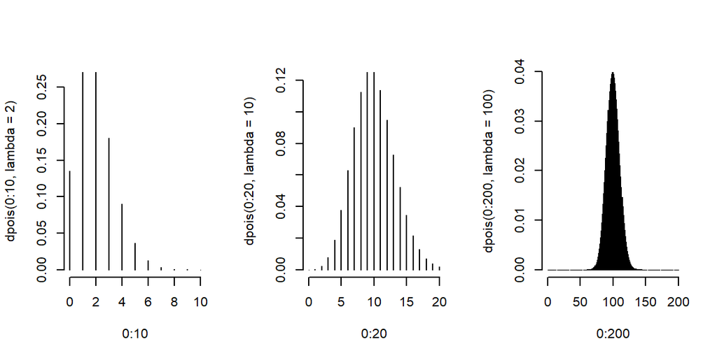

```r
# set up 1x3 panel plot
par(mfrow = c(1, 3))
# Poisson distribution for t = 1, and lambda = 2
plot(0 : 10, dpois(0 : 10, lambda = 2), type = "h", frame = FALSE)
# Poisson distribution for t = 1, and lambda = 10
plot(0 : 20, dpois(0 : 20, lambda = 10), type = "h", frame = FALSE)
# Poisson distribution for t = 1, and lambda = 100
plot(0 : 200, dpois(0 : 200, lambda = 100), type = "h", frame = FALSE)
```

- as we can see from above, for large values of $\lambda$, the distribution looks like the Gaussian

## 18.2 Example - Leek Group Website Traffic

- for this example, we will be modeling the daily traffic to Jeff Leek’s web site: http://biostat.jhsph.edu/~jleek/
  - the data comes from Google Analytics and was extracted by the `rga` package that can be found at http://skardhamar.github.com/rga/
- for the purpose of the example, the time is *always* one day, so $t = 1$, Poisson mean is interpreted as web hits per day
  - if $t = 24$, we would be modeling web hits per hour
- the data can be found [here](https://dl.dropboxusercontent.com/u/7710864/data/gaData.rda)

```r
# load data
load("./data/gaData.rda")
# convert the dates to proper formats
gaData$julian <- julian(gaData$date)
# look at the data
head(gaData)
```

```
##         date visits simplystats julian
## 1 2011-01-01      0           0  14975
## 2 2011-01-02      0           0  14976
## 3 2011-01-03      0           0  14977
## 4 2011-01-04      0           0  14978
## 5 2011-01-05      0           0  14979
## 6 2011-01-06      0           0  14980
```

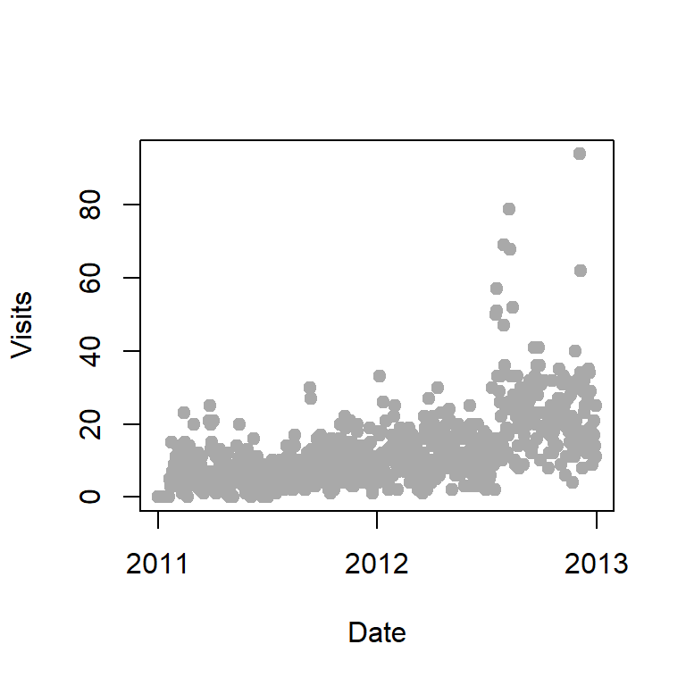

```r
# plot visits vs dates
plot(gaData$date,gaData$visits,pch=19,col="darkgrey",xlab="Date",ylab="Visits")
```

## 18.3 Example - Linear Regression

- the traffic can be modeled using linear model as follows
  $$NH_i = \beta_0 + \beta_1 D_i + \epsilon_i$$
  - $NH_i$ = number of hits to the website
  - $D_i$ = date
  - $\beta_0$ = number of hits on day 0 (1970-01-01)
  - $\beta_1$ = increase in number of hits per unit day
  - $\epsilon_i$ = variation due to everything we didn’t measure
- the expected outcome is defined as
  $$E[NH_i | JD_i, \beta_0, \beta_1] = \beta_0 + \beta_1 JD_i$$

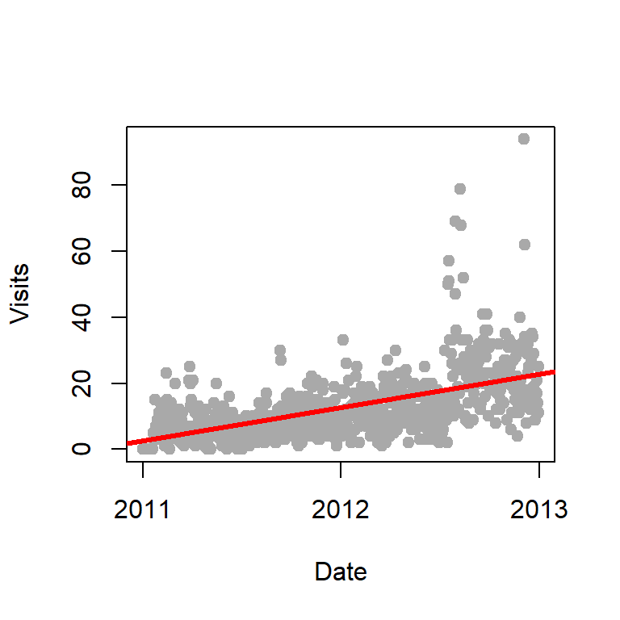

```r
# plot the visits vs dates
plot(gaData$date,gaData$visits,pch=19,col="darkgrey",xlab="Date",ylab="Visits")
# perform linear regression
lm1 <- lm(gaData$visits ~ gaData$date)
# plot regression line
abline(lm1, col="red", lwd=3)
```

- Clearly there’s some curvature there, maybe we should have put an x squared term in. But that would be our first approach to this, and honestly it wouldn’t be that bad. But the counts are kind of small, so it’s not the best thing in the world.
- The interpretation isn’t great for linear models, then we’ll see some ways which in the next couple of slides, how we can tweak linear models to maybe get a slightly better interpretation. I think that of counts in web hits and things like that as things that you would want to think about on a **relative scale** and the linear model really treats it on a linear additive scale. So let’s think about how we could get relative interpretations from our linear model. The first thing we might try is taking the **log of the outcome**

## 18.4 Example - log Outcome

- if we are interested in relative increases in web traffic, we can the natural log of the outcome, so the linear model becomes
  $$\log(NH_i) = \beta_0 + \beta_1 D_i + \epsilon_i$$
  - $\log(NH_i)$ = number of hits to the website
  - $D_i$ = date
  - $\beta_0$ = log number of hits on day 0 (1970-01-01)
  - $\beta_1$ = increase in log number of hits per unit day
  - $\epsilon_i$ = variation due to everything we didn’t measure
- when we take the natural log of outcomes and fit a regression model, the exponentiated coefficients ($e^{\beta_k}$) estimate quantities based on the geometric means rather than the measured values
  - $e^{E[\log(Y)]}$ = geometric mean of $Y$
    - the geometric mean is just exponentiating the arithmatic mean of the log data
    - geometric means are defined as
      $$e^{\frac{1}{n}\sum_{i=1}^n \log(y_i)} = (\prod_{i=1}^n y_i)^{1/n}$$
      which is the estimate for the **population geometric mean**
    - as we collect infinite amount of data, $(\prod_{i=1}^n y_i)^{1/n} \to E[\log(Y)]$ (geometric mean converges to the arithmatic mean of the log data)
  - exponentiated coefficients are interpretable with respect to geometric means
  - $e^{\beta_0}$ = estimated geometric mean hits on day 0
  - $e^{\beta_1}$ = estimated relative increase or decrease in geometric mean hits per day
  - This intercept doesn’t mean that much because January 1st 1970 is not a date that we care about in terms of number of web hits. So probably to make the intercept more interpretable, what we should have done is subtracted off the earliest date that we saw and started counting days from all of the remaining days in our data set. Then the exp of the estimated intercept would be the geometric mean hits on the first day of this data set.
  - **Note**: we can not take the natural log of zero counts, so often we need to adding a constant (i.e. 1) to construct the log model
    - adding the constant changes the interpretation of coefficient slightly
    - $e^{\beta_1}$ is now the relative increase or decrease in geometric mean hits **+ 1** per day
- the expected outcome is
  $$E[\log(NH_i | JD_i, \beta_0, \beta_1)] = \beta_0 + \beta_1 JD_i$$

```r
round(exp(coef(lm(I(log(gaData$visits + 1)) ~ gaData$date))), 5)
```

```
## (Intercept) gaData$date
##     0.00000     1.00231
```

- the intercept which is kind of irrelevant in this case, because we are using data since January 1st 1970
- then we get 1.002 for $\beta_1$. This is on the exponentiated scale. This means that our model is estimating a 0.2% increase in web traffic per day

## 18.5 Example - Poisson Regression

- the Poisson/log-linear model can be constructed as log of the mean
  $$\log\left(E[NH_i | D_i, \beta_0, \beta_1]\right) = \beta_0 + \beta_1 D_i$$
  or in other form
  $$E[NH_i | D_i, \beta_0, \beta_1] = \exp\left(\beta_0 + \beta_1 D_i\right)$$
  - $NH_i$ = number of hits to the website
  - $D_i$ = date
  - $\beta_0$ = expected number of hits on day 0 (1970-01-01)
  - $\beta_1$ = expected increase in number of hits per unit day
  - **Note**: Poisson model differs from the log outcome model in that the coefficients are interpreted naturally as expected value of outcome where as the log model is interpreted on the log scale of outcome
- we can transform the Poisson model to
  $$E[NH_i | D_i, \beta_0, \beta_1] = \exp\left(\beta_0 + \beta_1 D_i\right) = \exp\left(\beta_0 \right)\exp\left(\beta_1 D_i\right)$$
  - If $D_i$ is increased by one unit, $E[NH_i | D_i, b_0, b_1]$ is multiplied by $\exp\left(b_1\right)$, since
    $$\frac{\exp\left(\beta_0 + \beta_1 (D_i + 1)\right)}{\exp\left(\beta_0 + \beta_1 D_i\right)} = \exp(\beta_1)$$
  - So our coefficient, e to our slope coefficient, is interpreted as the **relative** increase or decrease in the mean per one unit change in the regressor
    - if we exponentiate our coefficient, we’re going to be looking at whether or not they’re close to 1
    - if we leave them on the log scale, we’re going to be looking at whether or not they’re close to 0
  - in our example $\exp(\beta_1)$ can therefore be interpreted as the expected **relative** increase/decrease in web traffic hits per one day increase
- `glm(outcome~predictor, family = "poisson")` = performs Poisson regression

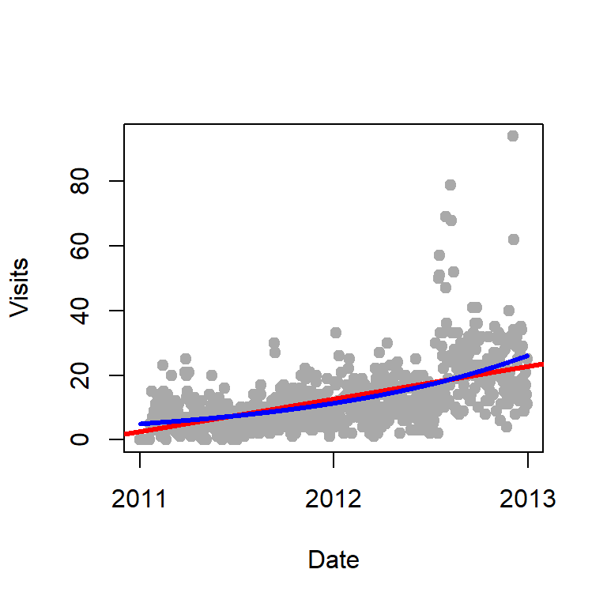

```r
# plot visits vs dates
plot(gaData$date,gaData$visits,pch=19,col="darkgrey",xlab="Date",ylab="Visits")
# construct Poisson regression model
glm1 <- glm(gaData$visits ~ gaData$date,family="poisson")
# plot linear regression line in red
abline(lm1,col="red",lwd=3)
# plot Poisson regression line in blue (represents mean number of visits per day, which is lambda)
lines(gaData$date,glm1$fitted,col="blue",lwd=3)
```

- **Note**: the Poisson fit is non-linear since it is linear only on the log of the mean scale

## 18.6 Example - Robust Standard Errors with Poisson Regression

- variance of the Poisson distribution is defined to be the mean of the distribution, so we would expect the variance to increase with higher values of $X$
- below are the residuals vs fitted value plot for the Poisson regression model

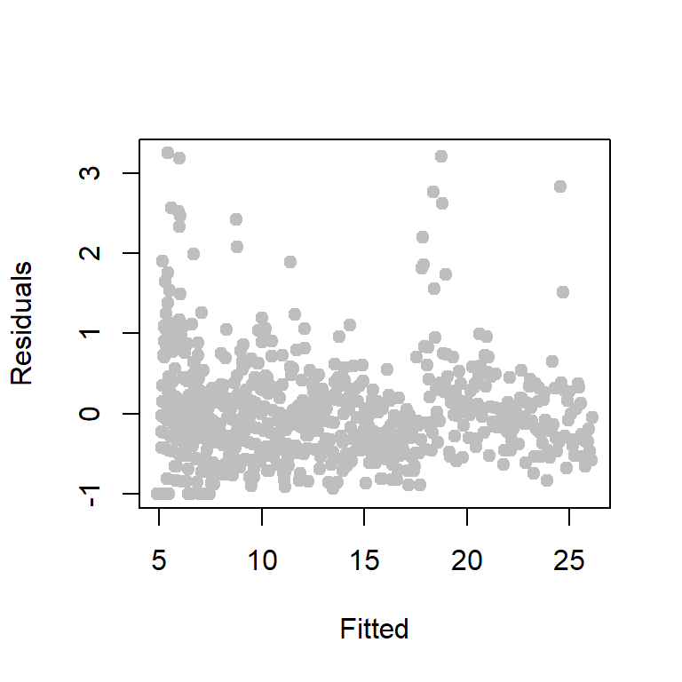

```r
# plot residuals vs fitted values
plot(glm1$fitted, glm1$residuals, pch=19, col="grey", ylab="Residuals", xlab="Fitted")
```

- as we can see from above, the residuals **don’t appear** to be increasing with higher fitted values (variance should increase with higher values of $X$)
- even if the mean model is correct in principle, there could always be a certain degree of *model mis-specification*
- to account for mis-specifications for the model, we can use
  1. `glm(outcome~predictor, family = "quasi-poisson")` = introduces an additional multiplicative factor $\phi$ to denominator of model so that the variance is $\phi \mu$ rather than just $\mu$ (see Variances and Quasi-Likelihoods)
  2. more generally, *robust standard errors* (effectively constructing wider confidence intervals) can be used
- **model agnostic standard errors**, implemented through the `sandwich` package, is one way to calculate the robust standard errors
  - algorithm assumes the mean relationship is specified correctly and attempts to get a general estimate of the variance that isn’t highly dependent on the model
  - it uses assumption of large sample sizes and asymptotics to estimate the confidence intervals that is robust to model mis-specification
  - **Note**: more information can be found at http://stackoverflow.com/questions/3817182/vcovhc-and-confidence-interval

```r
# load sandwich package
library(sandwich)
# compute
confint.agnostic <- function (object, parm, level = 0.95, ...)
{
    cf <- coef(object); pnames <- names(cf)
    if (missing(parm))
        parm <- pnames
    else if (is.numeric(parm))
        parm <- pnames[parm]
    a <- (1 - level)/2; a <- c(a, 1 - a)
    pct <- stats:::format.perc(a, 3)
    fac <- qnorm(a)
    ci <- array(NA, dim = c(length(parm), 2L), dimnames = list(parm,
                                                               pct))
    ses <- sqrt(diag(sandwich::vcovHC(object)))[parm]
    ci[] <- cf[parm] + ses %o% fac
    ci
}
# regular confidence interval from Poisson Model
confint(glm1)
```

```
##                     2.5 %        97.5 %
## (Intercept) -34.346577587 -31.159715656
## gaData$date   0.002190043   0.002396461
```

```r
# model agnostic standard errors
confint.agnostic(glm1)
```

```
##                     2.5 %        97.5 %
## (Intercept) -36.362674594 -29.136997254
## gaData$date   0.002058147   0.002527955
```

- as we can see from above, the robust standard error produced slightly wider confidence intervals
- **Note**: above CIs are on log scale. Use `exp(confint(glm1))` to get more interpretable values.

## 18.7 Example - Model Shortcoming

- Our model looks like a pretty good description of the data, but no model is perfect and we can often learn about a data generation process by looking for a model’s shortcomings.

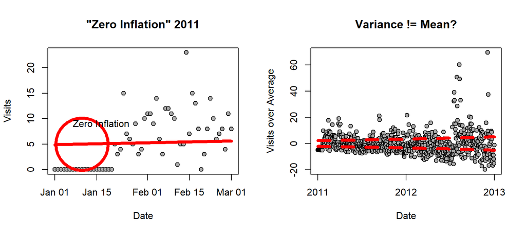

```r
idx <- 1:60
par(mfrow=c(1,2))
plot(visits ~ date, gaData[idx,],
     main='"Zero Inflation" 2011',
     xlab="Date", ylab="Visits", pch=21, bg='darkgrey')
lines(gaData$date[idx], glm1$fitted.values[idx], lwd=5, col="red")
points(as.Date("2011-01-10"), 5, cex=12, lwd=5, col="red")
text(as.Date("2011-01-5"), 9, "Zero Inflation", pos=4)
plot(gaData$date, gaData$visits-glm1$fitted.values, pch=21, bg='darkgrey', main="Variance != Mean?", xlab="Date", ylab="Visits over Average")
lines(gaData$date, sqrt(glm1$fitted.values), lwd=5, lty=2, col='red')
lines(gaData$date, -sqrt(glm1$fitted.values), lwd=5, lty=2, col='red')
```

- As shown in the figure, one thing about our model is ‘zero inflation’ in the first two weeks of January 2011, before the site had any visits. The model systematically overestimates the number of visits during this time.
- A less obvious thing is that the standard deviation of the data may be increasing with lambda faster than a Poisson model allows. This possibility can be seen in the rightmost plot by visually comparing the spread of grey dots with the standard deviation predicted by the model (red dashes.) Also, there are four or five bursts of popularity during which the number of visits far exceeds two standard deviations over average. Perhaps these are due to mentions on another site.
- It seems that at least some of them are. The `simplystats` column of our data records the number of visits to the Leek Group site which come from the related site, *Simply Statistics*. (ie., visits due to clicks on a link to the Leek Group which appeared in a Simply Statisics post.)

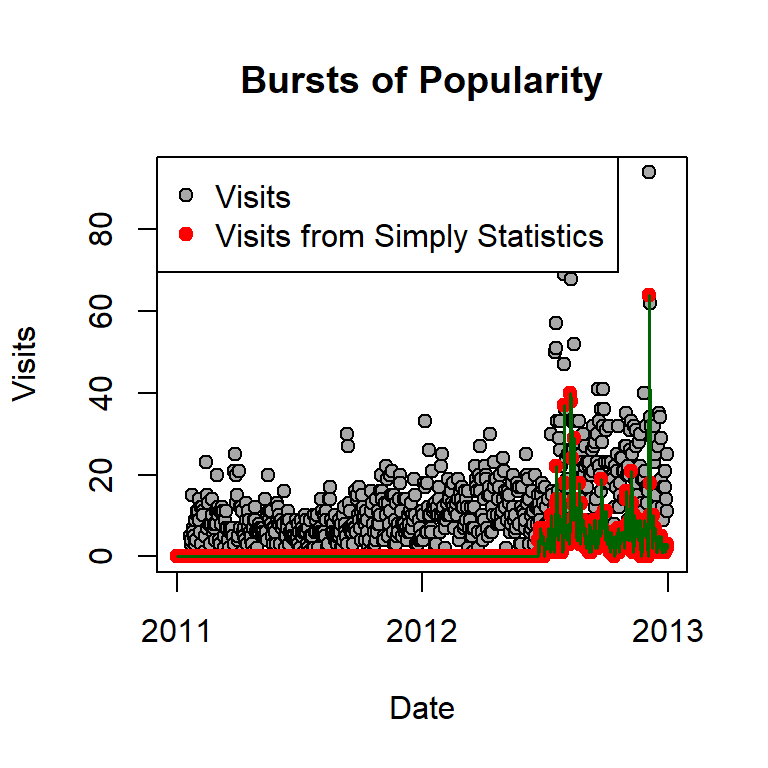

```r
par(mfrow=c(1,1))
plot(visits ~ date, gaData, pch=21, bg='darkgrey', main="Bursts of Popularity", xlab="Date", ylab="Visits")
points(simplystats ~ date, gaData, pch=19, col='red')
lines(simplystats ~ date, gaData, lwd=1.5, col='darkgreen')
legend('topleft', c("Visits", "Visits from Simply Statistics"), pch=c(21,19),
    pt.bg=c("darkgrey", "black"), col=c("black","red"), bg="white")
```

- In the figure, the maximum number of visits occurred in late 2012. Visits from the Simply Statistics blog were also at their maximum that day. To find the exact date we can use `which.max(hits[,'visits'])`.

```r
# maximum number of visits at this date
idx <- which.max(gaData[,"visits"])
gaData[idx,]
```

```
##           date visits simplystats julian
## 704 2012-12-04     94          64  15678
```

- The maximum number of visits, 94, occurred on December 4, 2012, of which 64 came from the Simply Statistics blog. We might consider the 64 visits to be a special event, over and above normal. Can the difference, 94-64=30 visits, be attributed to normal traffic as estimated by our model? To check, we will need the value of lambda (=expected number of visits) on December 4, 2012. The number of visits explained by our model on December 4, 2012 are those of a Poisson random variable with mean lambda. We can find the 95th percentile of this distribution using `qpois(.95, lambda)`.

```r
# expected number of visits (= lambda) at date with maximum visit
lambda <- glm1$fitted.values[idx]
# number of visits at the 95th percentile given by our model
qpois(.95, lambda)
```

```
## [1] 33
```

- So, 95% of the time we would see 33 or fewer visits, hence 30 visits would not be rare according to our model. It would seem that on December 4, 2012, the very high number of visits was due to references from Simply Statistics. To gauge the importance of references from Simply Statistics we may wish to model the proportion of traffic such references represent. Doing so will also illustrate the use of glm’s parameter, `offset`, to model frequencies and proportions.

## 18.8 Example - Rates

- A Poisson process generates counts, and counts are whole numbers, 0, 1, 2, 3, etc. A proportion (or rate) is a fraction. So how can a Poisson process model a proportion? The trick is to include the denominator of the fraction, or more precisely its log, as an offset.
  - Assume an instance where you have a count, and then you have some offset that should tell you how large or small the count should be.
  - For example, if I’m counting failures of my nuclear pumps that I mentioned before, I should have more failures if I monitored them for a longer time. If I’m counting the number of flu cases, I should have more flu cases if I’m looking at a larger population. So I should have more flu cases in a bigger city than I would have in a smaller city.
  - So in all these cases, if the counts that we’re interested in have some term that we really want to interpret our count relative to that, whether it’s a unit of time, person, time at risk, total sample size, then the first thing we note is that we want to actually interpret not the expected value of the outcome, but the expected value of the outcome divided by this relative term
- in this case, we are looking at the number of web hits originating from Simply Statistic blog, relative to the total number of web hits
  $$\begin{aligned}
  E[NHSS_i | D_i, \beta_0, \beta_1]/NH_i & = \exp\left(\beta_0 + \beta_1 D_i\right) \\
  (take~\log~of~both~sides)~\log\left(E[NHSS_i | D_i, \beta_0, \beta_1]\right) - \log(NH_i) & = \beta_0 + \beta_1 D_i \\
  (move~\log(NH_i)~to~right~side)~\log\left(E[NHSS_i | D_i, \beta_0, \beta_1]\right) & = \log(NH_i) + \beta_0 + \beta_1 D_i \\
  \end{aligned}$$
  - when **offset** term $\log(NH_i)$ is present in the Poisson model, the interpretation of the coefficients will be **relative to the offset quantity**
  - it’s important to recognize that the fitted response doesn’t change
  - *Example*: to convert the outcome from daily data to hourly, we can add a factor 24 so that the model becomes
    $$\begin{aligned}
    E[NHSS_i | D_i, \beta_0, \beta_1]/24 & = \exp\left(\beta_0 + \beta_1 D_i\right) \\
    (take~\log~of~both~sides)~\log\left(E[NHSS_i | D_i, \beta_0, \beta_1]\right) - \log(24) & = \beta_0 + \beta_1 D_i \\
    (move~\log(24)~to~right~side)~\log\left(E[NHSS_i | D_i, \beta_0, \beta_1]\right) & = \log(24) + \log(NH_i) + \beta_0 + \beta_1 D_i \\
    \end{aligned}$$
- As shown, we would like to model the fraction simplystats/visits, but to avoid division by zero we’ll actually use simplystats/(visits+1).
- We fit the Poisson model now with an `offset` so that the model is interpreted with respect to the number of visits
  - `glm(outcome ~ predictor, offset = log(offset), family = "poisson")` = perform Poisson regression with offset
  - `glm(outcome ~ predictor + log(offset))` = produces the same result
  - ***Note**: glm’s parameter, `offset`, fixes the coefficient of the offset to 1, so that the fraction simplystats/visits can hold
- below is a plot of the difference between the GLM1 fitted rates, which was to the number of web hits, versus the GLM2 fitted rates, which was the relative number of web hits originating from Simply Statistics (So these blue points are adjusted for the red points in a sense)

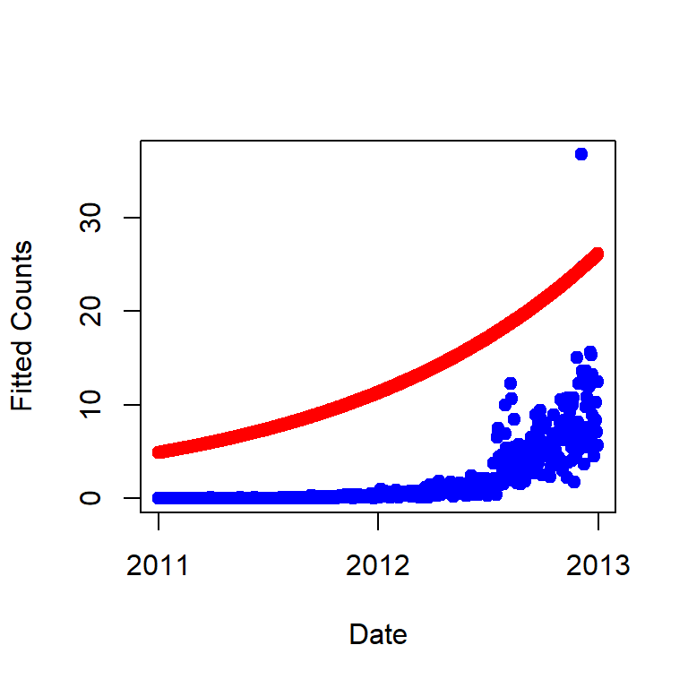

```r
# perform Poisson regression with offset for number of visits
glm2 <- glm(simplystats ~ date, offset=log(visits+1), family="poisson", data=gaData)
# plot the fitted means (from simply statistics) in BLUE
plot(gaData$date, glm2$fitted,col="blue", pch=19,xlab="Date", ylab="Fitted Counts")
# plot the fitted means (total visit) in RED
points(gaData$date, glm1$fitted, col="red", pch=19)
```

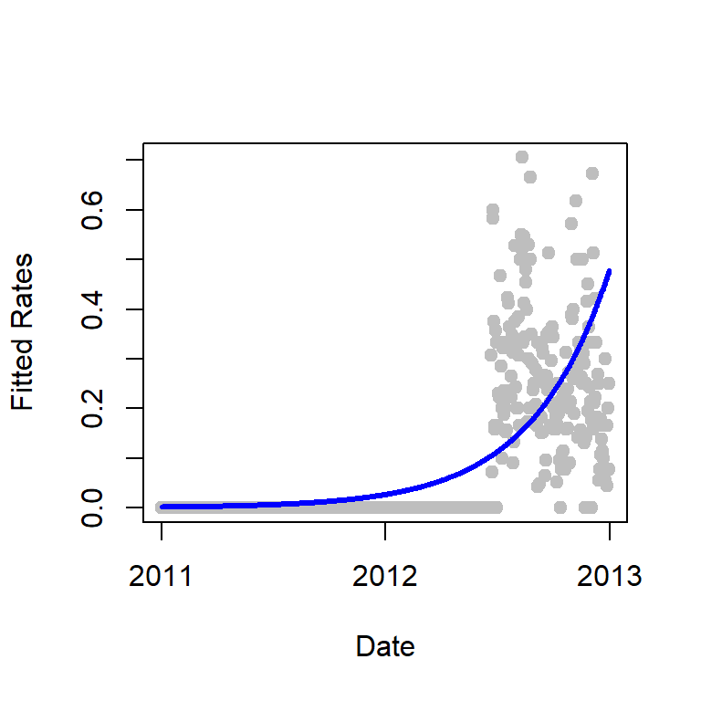

```r
# plot the rates for simply stats (actual data points)
plot(gaData$date, gaData$simplystats/(gaData$visits+1), col="grey",xlab="Date",
     ylab="Fitted Rates", pch=19)
# plot the fitted rates for simply stats (visit/day) (fitted model)
lines(gaData$date, glm2$fitted/(gaData$visits+1), col="blue", lwd=3)
```

- Above plot shows the fitted model (blue line) relative to the data (gray points): there are a lot of zeros early on, and then it took off quite a bit
- Although `summary(glm2)` will show that the estimated coefficients are significantly different than zero, the model is actually not impressive. We can illustrate why by looking at December 4, 2012, once again. On that day there were 64 actual visits from Simply Statistics. However, according to `glm2`, 64 visits would be extremely unlikely. You can verify this weakness in the model by finding glm2’s 95th percentile for that day.

```r
# number of visits at the 95th percentile given by our model (should be 64)
qpois(.95, glm2$fitted.values[idx])
```

```
## [1] 47
```

## 18.9 Further Resources

- [Log-linear mMdels and Multi-way Tables](http://ww2.coastal.edu/kingw/statistics/R-tutorials/loglin.html)
- [Wikipedia on Poisson Regression](http://en.wikipedia.org/wiki/Poisson_regression)
- [Wikipedia on Overdispersion](http://en.wikipedia.org/wiki/Overdispersion)
- [Regression Models for count data in R](http://cran.r-project.org/web/packages/pscl/vignettes/countreg.pdf)
- [`pscl` package](http://cran.r-project.org/web/packages/pscl/index.html) -
  - often time in modeling counts, there may be **more zero counts** in the data than anticipated, which the regular Poisson model doesn’t account for
  - the function `zeroinfl` fits zero inflated Poisson (ziP) models to such data

# 19 Fit Functions Using Linear Models

- **Intro**: Extend linear models so that we can fit complicated functions using regression models. We’ve seen a little bit in how to do this by adding squared and cubic or polynomial terms into our regression model so that we can fit lower order functions. However imagine if you have a complicated function like a sine curve or something that looks maybe like a sine curve. How would you fit that non-parametrically using a linear model?
- **scatterplot smoothing** = fitting functions (multiple linear models, piece-wise zig-zag lines) to data in the form $Y_i = f(X_i) + \epsilon_i$
- consider the model
  $$Y_i = \beta_0 + \beta_1 X_i + \sum_{k=1}^d (x_i - \xi_k)_+ \gamma_k + \epsilon_{i}$$
  where $(a)_+ = a$ if $a > 0$ and $0$ otherwise and $\xi_1 \leq ... \leq \xi_d$ are known **knot points**
- the mean function
  $$E[Y_i] = \beta_0 + \beta_1 X_i + \sum_{k=1}^d (x_i - \xi_k)_+ \gamma_k$$
  is continuous at the knot points
  - for $\xi_k = 5$, the expected value for $Y_i$ as $x_i$ approaches 5 from the left is
    $$\begin{aligned}
    E[Y_i]_{\xi = 5 | left} & = \beta_0 + \beta_1 x_i + (x_i - 5)_+ \gamma_k \\
    (since~x_i<5)~ E[Y_i]_{\xi = 5 | left} & = \beta_0 + \beta_1 x_i \\
    \end{aligned}$$
  - the expected value for $Y_i$ as $x_i$ approaches 5 from the right is
    $$\begin{aligned}
    E[Y_i]_{\xi = 5 | right} & = \beta_0 + \beta_1 x_i + (x_i - 5)_+ \gamma_k \\
    (since~x_i>5)~ E[Y_i]_{\xi = 5 | right} & = \beta_0 + \beta_1 x_i + (x_i - 5) \gamma_k\\
    (simplify)~ E[Y_i]_{\xi = 5 | right} & = \beta_0 - 5 \gamma_k + (\beta_1 + \gamma_k) x_i \\
    \end{aligned}$$
  - as we can see from above, the right side is just another line with different intercept ($\beta_0 - 5 \gamma_k$) and slope ($\beta_1 + \gamma_k$)
  - so as $x$ approaches 5, both sides converge

## 19.1 Considerations

- **basis** = the collection of regressors
- single knot point terms can fit *hockey-stick-like* processes
- these bases can be used in GLMs (as an additional term/predictor) as well
- issue with these approaches is the **large** number of parameters introduced
  - requires some method of *regularization*, or penalize for large number of parameters (see **Practical Machine Learning** course)
  - introducing large number of knots have significant consequences

## 19.2 Example - Fitting Piecewise Linear Function

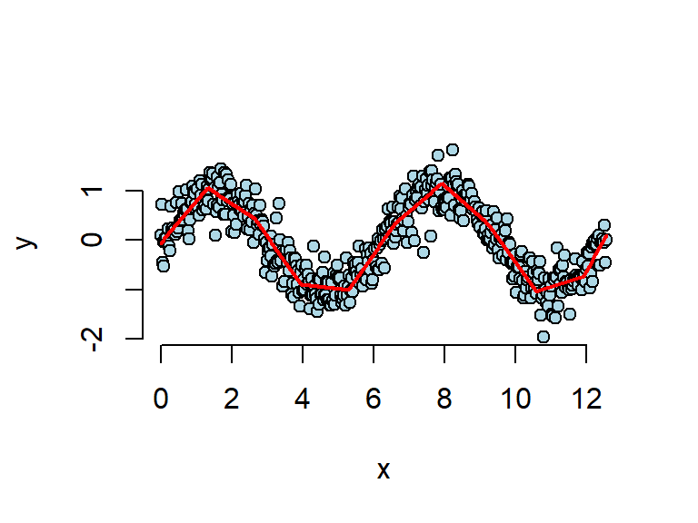

```r
# simulate data: sin curve + noise
n <- 500; x <- seq(0, 4 * pi, length = n); y <- sin(x) + rnorm(n, sd = .3)
# define 20 knot points, equally spread along the data
knots <- seq(0, 8 * pi, length = 20);
# define the ()+ function to only take the values that are positive after the knot pt
splineTerms <- sapply(knots, function(knot) (x > knot) * (x - knot))
# define the predictors as X and spline term
xMat <- cbind(x, splineTerms)
# fit linear models for y vs predictors
yhat <- predict(lm(y ~ xMat))
# plot data points (x, y)
plot(x, y, frame = FALSE, pch = 21, bg = "lightblue")
# plot fitted values
lines(x, yhat, col = "red", lwd = 2)
```

## 19.3 Example - Fitting Piecewise Quadratic Function

- adding squared terms makes it *continuous* AND *differentiable* at the knot points, and the model becomes
  $$Y_i = \beta_0 + \beta_1 X_i + \beta_2 X_i^2 + \sum_{k=1}^d (x_i - \xi_k)_+^2 \gamma_k + \epsilon_{i}$$
  where $(a)^2_+ = a^2$ if $a > 0$ and $0$ otherwise
- adding cubic terms makes it twice continuously differentiable at the knot points, etcetera

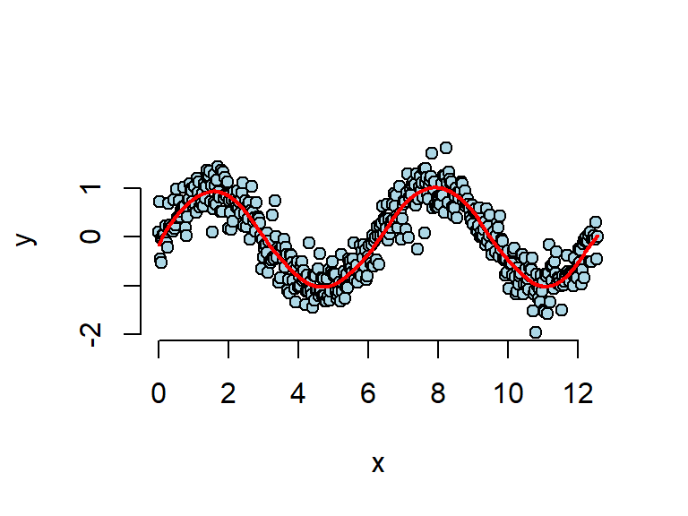

```r
# define the knot terms in the model
splineTerms <- sapply(knots, function(knot) (x > knot) * (x - knot)^2)
# define the predictors as x, x^2 and knot terms
xMat <- cbind(x, x^2, splineTerms)
# fit linear models for y vs predictors
yhat <- predict(lm(y ~ xMat))
# plot data points (x, y)
plot(x, y, frame = FALSE, pch = 21, bg = "lightblue")
# plot fitted values
lines(x, yhat, col = "red", lwd = 2)
```

## 19.4 Example - Harmonics using Linear Models

- using Fourier bases
- **discrete Fourier transforms** = instance of linear regression model, use sin and cosine functions as basis to fit data
- to demonstrate this, we will generate 2 seconds of sound data using sin waves, simulate a chord, and apply linear regression to find out which notes are playing

```r
# frequencies for white keys from c4 to c5
notes4 <- c(261.63, 293.66, 329.63, 349.23, 392.00, 440.00, 493.88, 523.25)
# generate sequence for 2 seconds
t <- seq(0, 2, by = .001); n <- length(t)
# define data for c4 e4 g4 using sine waves with their frequencies
c4 <- sin(2 * pi * notes4[1] * t); e4 <- sin(2 * pi * notes4[3] * t);
g4 <- sin(2 * pi * notes4[5] * t)
# define data for a chord and add a bit of noise
chord <- c4 + e4 + g4 + rnorm(n, 0, 0.3)
# generate profile data for all notes
x <- sapply(notes4, function(freq) sin(2 * pi * freq * t))
# fit the chord using the profiles for all notes
fit <- lm(chord ~ x - 1)
```

- after generating the data and running the linear regression, we can plot the results to see if the notes are correctly identified

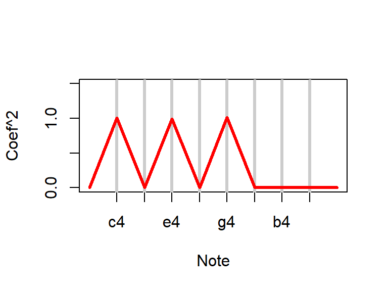

```r
# set up plot
plot(c(0, 9), c(0, 1.5), xlab = "Note", ylab = "Coef^2", axes = FALSE, frame = TRUE, type = "n")
# set up axes
axis(2)
axis(1, at = 1 : 8, labels = c("c4", "d4", "e4", "f4", "g4", "a4", "b4", "c5"))
# add vertical lines for each note
for (i in 1 : 8) abline(v = i, lwd = 3, col = grey(.8))
# plot the linear regression fits
lines(c(0, 1 : 8, 9), c(0, coef(fit)^2, 0), type = "l", lwd = 3, col = "red")
```

- as we can see from above, the correct notes were identified (using only sine functions)
- we can also use the [**Fast Fourier Transforms**](http://en.wikipedia.org/wiki/Fast_Fourier_transform) to identify the notes (using sine and cosine functions)
  - `fft(data)` = performs fast Fourier transforms on provided data
  - `Re(data)` = subset to only the real components of the complex data

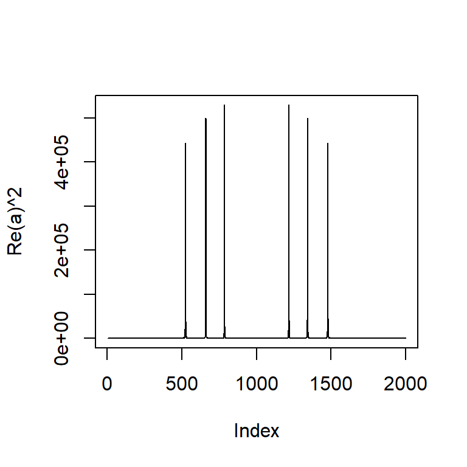

```r
# perform fast fourier transforms on the chord matrix
a <- fft(chord)
# plot only the real components/frequencies of the fft
plot(Re(a)^2, type = "l")
```

- **Note**: the algorithm checks for all possible notes at all frequencies it can detect, which is why the peaks are very high in magnitude
- **Note**: the symmetric display of the notes are due to periodic symmetries of the sine functions